# Botamin Voice Sales Agent — техническая спецификация

React + Bun + xAI STT + OpenRouter TTS + Codex subscription / GPT-5.6 Luna

Architecture & delivery handoff

31 июля 2026

# Botamin Voice Sales Agent — техническая спецификация

**Версия:** 0.4-demo

**Статус:** основа для передачи агентам-разработчикам

**Deployment target:** одна trusted VPS, один Docker Compose

**Runtime split:** xAI Streaming STT → Codex app-server / `gpt-5.6-luna` → OpenRouter TTS (native Bun fetch, complete MP3 phrase segments)

> Ключевой инвариант: внутренняя бронь создаётся до любой опциональной квалификации. После `booking.created` отказ, обрыв или ошибка квалификации не отменяют и не удаляют лид.

## Карта пакета

Эта сводная версия объединяет scope, PRD, исследование Botamin, архитектуру, conversation design, API/data contracts, deployment/security, ADR, тестирование, сравнение AI-библиотек и parallel delivery plan. Machine-readable backlog и отдельные задания агентам находятся в `tasks/`. TTS decisions follow `corrections/CORRECTION-003_OPENROUTER_TTS_TYPESCRIPT_NATIVE.md`; correction files are intentionally not assembled into this generated document.

# 00. Scope, допущения и терминология

## 1. Цель MVP

Продемонстрировать работающий вертикальный срез AI-продавца Botamin:

> посетитель открывает лендинг, начинает голосовой разговор, получает релевантную презентацию продукта, отвечает на уточняющие вопросы, соглашается на встречу, передаёт минимальный контакт, после чего backend фиксирует бронь и опционально обогащает её квалификацией.

MVP должен выглядеть как небольшой реальный продукт, а не как набор несвязанных API-примеров.

## 2. Участники

| Участник | Роль |
| --- | --- |
| Посетитель | потенциальный B2B-клиент Botamin |
| Голосовой AI-продавец | ведёт разговор и достигает целевого действия |
| Backend | владеет состоянием, tools, транзакциями и аудитом |
| Получатель лида | в MVP читает console/webhook/push payload |
| Владелец проекта | редактирует Markdown prompts в Git |

## 3. В scope

- адаптивный лендинг Botamin;
- браузерный доступ к микрофону;
- потоковый STT на русском;
- текстовое рассуждение и ответ через GPT-5.6 Luna в Codex;
- phrase-level TTS через полные MP3-сегменты, запускаемый до завершения полного ответа;
- interruption/barge-in на базовом уровне;
- управляемая state machine разговора;
- product knowledge из Botamin-сайта и Telegram-кейсов;
- создание внутренней брони;
- необязательная квалификация после брони;
- SQLite persistence;
- console notifier и интерфейс для webhook/push;
- transcript/event audit;
- Docker Compose, TLS, health checks, backup;
- тесты контрактов, компонентов, E2E и conversation evals.

## 4. Вне scope

- визуальный conversation builder;
- prompt CMS, роли и авторизация редакторов;
- реальный Google Calendar, Calendly или CRM;
- проверка свободных слотов;
- телефония, SIP, PSTN, Twilio;
- исходящие звонки;
- полноценный call-center dashboard;
- биллинг и multi-tenant;
- Kubernetes, autoscaling, микросервисное дробление;
- отдельная vector database и сложный RAG;
- хранение аудиозаписей по умолчанию;
- юридическая экспертиза privacy copy.

## 5. Зафиксированные defaults

| Вопрос | Default MVP |
| --- | --- |
| Язык | русский; структура допускает локализацию |
| Канал | браузерный voice widget |
| Мозг | Codex app-server, `gpt-5.6-luna` |
| Voice | xAI Streaming STT + OpenRouter TTS через backend-only TypeScript/Bun adapter |
| TTS profile | `x-ai/grok-voice-tts-1.0` / `eve` / `mp3`, все значения конфигурируемы; usage платный, бесплатный tier не предполагается |
| Backend | Bun + TypeScript, Hono как лёгкий HTTP/WS слой |
| Frontend | React + TypeScript + Vite |
| Storage | SQLite в WAL-режиме, Drizzle migrations |
| Notifications | console обязательно; webhook — адаптер |
| Calendar | отсутствует |
| Prompts | Markdown в Git |
| Deployment | один Compose project на одной VPS; только app + Caddy в P0 application path |
| Raw audio retention | выключено |
| Qualification | включаемая опция, только после booking |

## 6. Допущения, которые агенты не должны превращать в блокеры

- Как минимум один контактный канал обязателен: телефон, email или Telegram.
- Предпочтительное время хранится свободным текстом; календарного slot resolution нет.
- Логотипы, точная типографика и brand book могут быть заменены аккуратным нейтральным стилем.
- Console output является достаточным handoff для P0.
- Если subscription auth временно недоступен, сервис показывает понятный degraded state; автоматический переход на платный API не включается без конфигурации.
- Числовые кейсы на лендинге используются только с подписью источника и без обещания повторить результат.

## 7. Термины

- **Conversation** — одна пользовательская голосовая сессия.
- **Turn** — одна завершённая реплика пользователя и следующий ответ агента.
- **Booking** — внутренняя запись о согласованном следующем шаге, не календарное событие.
- **Qualification** — необязательные сведения, добавляемые к уже существующей брони.
- **BrainPort** — внутренний интерфейс текстового LLM-мозга.
- **VoicePort** — provider-neutral внутренние `SttPort` и `TtsPort`; один TTS request возвращает один полный `audio/mpeg` phrase segment.
- **Barge-in** — пользователь начинает говорить во время ответа агента.
- **Tool** — строго валидируемая backend-операция с доменным эффектом.
- **Luna** — модель `gpt-5.6-luna`, доступная через Codex.

# 01. Product Requirements Document

## 1. Продуктовая формулировка

Botamin Voice Sales Agent — это лендинг с живой голосовой демонстрацией продукта: AI-продавец сам показывает, как Botamin может отвечать, квалифицировать, обрабатывать возражения и передавать менеджеру структурированный результат.

### North Star для MVP

**Доля начатых голосовых разговоров, в которых backend получил валидный `booking.created`.**

Не следует оптимизировать MVP под длительность разговора или количество реплик: главная ценность — качественно зафиксированный следующий шаг.

## 2. Целевая аудитория

Основные роли:

- собственник / CEO;
- Head of Sales / коммерческий директор;
- CMO / руководитель лидогенерации;
- руководитель первой линии;
- операционный руководитель, отвечающий за SLA обработки лидов.

Типовые контексты:

- лиды теряются ночью или в выходные;
- менеджеры долго отвечают;
- большой объём нецелевых обращений;
- требуется реактивация или обработка холодной базы;
- квалификация и CRM-рутина перегружают команду;
- нужно быстро протестировать AI-сценарий продаж.

## 3. User stories P0

| ID | История | Приёмка |
| --- | --- | --- |
| US-001 | Как посетитель, я запускаю разговор одной кнопкой | запрашивается mic permission, UI показывает состояние |
| US-002 | Я говорю естественно по-русски | interim transcript отображается, финал не режет фразу посередине |
| US-003 | Агент отвечает голосом и текстом | первая полная MP3-фраза может проиграться до завершения ответа Luna; ответ не содержит markdown-мусора |
| US-004 | Агент понимает, зачем я пришёл | задаёт не более одного вопроса за раз, фиксирует роль/задачу |
| US-005 | Агент объясняет Botamin на релевантном примере | использует только утверждённые knowledge claims |
| US-006 | Я могу возразить или перебить | проигрывание останавливается, новый turn обрабатывается |
| US-007 | Я соглашаюсь на встречу | агент собирает минимум данных и вызывает `create_booking` |
| US-008 | После брони я могу ответить на доп. вопросы | данные патчат ту же бронь через `append_booking_qualification` |
| US-009 | Я могу отказаться от квалификации | бронь остаётся `booked`, диалог корректно завершается |
| US-010 | Получатель видит данные | console/webhook получает структурированный payload |
| US-011 | Сервис перезапускается | сохранённые booking/event данные остаются в volume |
| US-012 | Проект разворачивается на VPS | `docker compose up -d` поднимает готовый сервис |

## 4. Functional requirements

### 4.1 Voice session

- **FR-VOICE-001:** создание сессии должно выдавать уникальный `conversationId`.
- **FR-VOICE-002:** браузер передаёт mono PCM16, 16 kHz, чанками около 100 ms.
- **FR-VOICE-003:** backend держит xAI credentials только server-side.
- **FR-VOICE-004:** partial transcript доступен UI; в Luna отправляется только финальная пользовательская реплика.
- **FR-VOICE-005:** при barge-in клиент немедленно останавливает playback и очищает очередь, backend abort-ит OpenRouter fetches текущего `generationId` и по возможности вызывает `turn/interrupt`.
- **FR-VOICE-006:** reconnect не должен создавать вторую бронь.
- **FR-VOICE-007:** stop завершает внешние соединения и фиксирует событие.
- **FR-VOICE-008:** OpenRouter вызывается только backend-ом; browser получает provider-neutral полные `audio/mpeg` phrase segments в sequence order.
- **FR-VOICE-009:** TTS failure сохраняет видимый текст и все уже committed business side effects; synthesis retry не повторяет brain turn или tools.
- **FR-VOICE-010:** перед TTS удаляются PII, tool envelopes, hidden IDs, Markdown, code fences и raw URLs; hard limit сегмента — configurable, default 240 chars.
- **FR-VOICE-011:** per-segment, per-turn и per-session character budgets, concurrency и response-size guards переводят audio path в text-only mode без изменения видимого ответа.

### 4.2 Brain and orchestration

- **FR-BRAIN-001:** модель по умолчанию `gpt-5.6-luna`; фактическая модель задаётся `CODEX_MODEL`, но её смена требует повторного conversation eval gate.
- **FR-BRAIN-002:** один Codex thread соответствует одной conversation.
- **FR-BRAIN-003:** backend, а не LLM, является источником истины для текущего stage.
- **FR-BRAIN-004:** LLM не получает shell/network privileges, кроме явно зарегистрированных доменных tools.
- **FR-BRAIN-005:** ответы проходят speech sanitizer перед TTS.
- **FR-BRAIN-006:** system/product/conversation prompts загружаются из Markdown.
- **FR-BRAIN-007:** tool mode имеет feature flag: `dynamic` и стабильный fallback `envelope`.
- **FR-BRAIN-008:** reasoning effort задаётся конфигурацией; стартовый профиль Luna использует минимальный уровень, который проходит quality evals.

### 4.3 Booking

- **FR-BOOK-001:** обязательны `conversationId`, имя и хотя бы один контактный канал.
- **FR-BOOK-002:** `create_booking` атомарен и идемпотентен по `conversationId`/`idempotencyKey`.
- **FR-BOOK-003:** успешный tool всегда возвращает стабильный `bookingId`.
- **FR-BOOK-004:** событие `booking.created` отправляется до первого квалификационного вопроса.
- **FR-BOOK-005:** meeting/calendar event не создаётся.
- **FR-BOOK-006:** агент подтверждает только факт получения данных.

### 4.4 Post-booking qualification

- **FR-QUAL-001:** запускается только при `booking.status=booked`.
- **FR-QUAL-002:** пользователь явно или контекстно соглашается на дополнительные вопросы.
- **FR-QUAL-003:** каждое осмысленное подмножество данных может сохраняться patch-операцией.
- **FR-QUAL-004:** поля qualification необязательны.
- **FR-QUAL-005:** disconnect/decline переводит qualification в `partial` или `skipped`, но booking остаётся `booked`.
- **FR-QUAL-006:** повторный patch идемпотентен.

### 4.5 Landing and UX

- **FR-WEB-001:** above-the-fold объясняет продукт и содержит один primary CTA.
- **FR-WEB-002:** до запуска голоса показывается понятное объяснение микрофона и обработки данных.
- **FR-WEB-003:** UI имеет состояния `idle`, `connecting`, `listening`, `thinking`, `speaking`, `booked`, `complete`, `error`.
- **FR-WEB-004:** текстовая копия реплик доступна для accessibility/debug.
- **FR-WEB-005:** mobile viewport поддерживается.
- **FR-WEB-006:** при voice failure пользователю не показываются stack traces/provider details.

## 5. P1 и P2

### P1

- generic signed webhook notifier с retry;
- dev-only inspector с событиями и latency;
- prompt checksum в каждом conversation;
- TTS cache для статических приветствий;
- automated conversation eval suite;
- basic abuse/rate limiting;
- export одного лида в JSON.

### P2

- Telegram notifier;
- A/B prompts;
- admin dashboard;
- real CRM/calendar adapters;
- selectable voices;
- multilingual flows;
- analytics warehouse.

## 6. Non-functional requirements

| ID | Требование | Цель MVP |
| --- | --- | --- |
| NFR-LAT-001 | speech-final → playback первой полной MP3-фразы | p50 ≤ 1.6 s, p95 ≤ 3.0 s; подтвердить измерением release profile |
| NFR-REL-001 | успешность `create_booking` при валидных данных | ≥ 99.5% внутри приложения |
| NFR-IDEM-001 | дубли брони при retry/reconnect | 0 в тестовой матрице |
| NFR-SEC-001 | TLS | обязательно в production |
| NFR-SEC-002 | raw credentials в клиентском bundle/logs | 0 |
| NFR-PRIV-001 | raw audio storage | off by default |
| NFR-OBS-001 | traceability | `conversationId`, `turnId`, `bookingId` во всех событиях |
| NFR-OPS-001 | deployment | один compose project |
| NFR-OPS-002 | backup | ежедневная копия SQLite + restore check |
| NFR-COMP-001 | browser | актуальные Chrome, Edge, Safari; Firefox best effort |
| NFR-A11Y-001 | keyboard/control labels | WCAG-oriented базовый уровень |

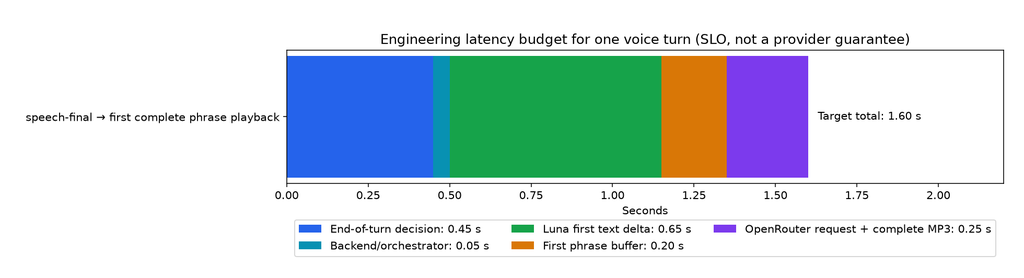

Целевой latency budget

Значения на графике — инженерный бюджет и release target, а не обещание провайдера. Реальные p50/p95 должны собираться в E2E.

## 7. Бизнес-события воронки

Минимальный набор:

1. `landing.viewed`
2. `voice.cta_clicked`
3. `voice.permission_granted` / `voice.permission_denied`
4. `conversation.started`
5. `conversation.discovery_completed`
6. `booking.offered`
7. `booking.created`
8. `qualification.started`
9. `qualification.updated`
10. `conversation.completed`
11. `conversation.failed`

## 8. Success metrics после запуска

- start rate: `conversation.started / landing.viewed`;
- speech activation: доля с хотя бы одной финальной репликой;
- booking conversion: `booking.created / conversation.started`;
- post-booking qualification opt-in;
- qualification completeness;
- drop-off stage distribution;
- p50/p95 time-to-first-audio;
- provider error rate, OpenRouter circuit state и доля text-only degradation;
- OpenRouter TTS character usage без spoken-text logging;
- duplicate booking rate;
- доля диалогов с manual review flag.

Метрики качества продаж нельзя интерпретировать без объёма трафика и human review выборки.

# 02. Исследование Botamin и проект воронки

## 1. Источники и ограничение

Исследованы:

- публичный сайт `https://botamin.ru/`;
- публичная лента Telegram `https://t.me/GPT_for_sales`;
- согласованный scope из текущего диалога.

Страница Notion была недоступна. Поэтому этот документ является продуктовым research brief для MVP, а не дословным пересказом исходного тестового.

## 2. Что продаёт Botamin

Сайт позиционирует Botamin как платформу AI-агентов, которая:

- автоматизирует первую линию продаж;
- генерирует и квалифицирует лиды из холодных и входящих источников;
- доводит лид до ключевого этапа воронки;
- работает с входящими, реактивацией и холодными базами;
- отвечает круглосуточно;
- передаёт результат менеджерам и в CRM;
- использует анализ диалогов для улучшения сценариев.

На сайте выделены доказательства и обещания: внедрение «под ключ», большое число внедрений, CRM-интеграции, быстрый ответ и кейсы из разных отраслей. В voice funnel эти тезисы лучше использовать не списком, а в ответ на конкретную боль собеседника.

## 3. Повторяющиеся pain patterns

| Pain | Что обещает сценарий Botamin | Как спросить в разговоре |
| --- | --- | --- |
| медленная реакция | быстрый ответ 24/7 | «Сколько сейчас проходит от заявки до первого контакта?» |
| ночные/выходные лиды | непрерывная первая линия | «Есть заметный входящий поток вне рабочего времени?» |
| нецелевые обращения | автоматическая квалификация | «Какую долю обращений менеджеры отсеивают вручную?» |
| недозвоны/молчуны | follow-up и реактивация | «Что происходит с теми, кому менеджер не дозвонился?» |
| рутина CRM | структурированный handoff | «Менеджеры сами заполняют карточки после разговора?» |
| холодная база | выход на ЛПР и квалификация | «Есть база, которую команда не успевает системно отрабатывать?» |
| нестабильные скрипты | единый сценарий + итерации | «Насколько одинаково менеджеры проводят первую квалификацию?» |

## 4. Что найдено в кейсах

Публичная Telegram-лента содержит кейсы, подходящие как social proof. Числа ниже являются утверждениями источника и не должны подаваться как гарантированный результат будущего клиента.

| Сценарий | Опубликованный результат | Применение в funnel |
| --- | --- | --- |
| «Главтрассы», голосовой outbound | 15% в квалифицированный лид; резюме и транскрипция в Telegram | пример выхода на ЛПР и передачи тёплого лида |
| РоллПроф, входящий + follow-up | 13% доведены до реального интереса | 24/7 и работа с недозвонами |
| продавец утеплительной пены на Авито | рост конверсии с 10% до 45% по публикации | скорость ответа и фильтрация нецелевых |
| поставщик стройматериалов | 1000 обращений, 31% горячих лидов, нагрузка пяти менеджеров | масштаб и квалификация по предметным полям |
| Foxford / сценарий недозвонов | возвращённая и квалифицированная часть пропущенных контактов | реактивация после неуспешного звонка |

### Правило claims

В prompt/knowledge нужно разделить:

- **Product facts:** что платформа умеет и как реализуется.
- **Case claims:** что было опубликовано в конкретном кейсе.
- **Prohibited promises:** «мы гарантированно поднимем конверсию в X раз», «заменим отдел», «окупимся за N дней».

## 5. Предлагаемый landing narrative

### Блок 1. Hero

**Заголовок:**

> AI-продавец, который сам покажет, как перестать терять лиды

**Подзаголовок:**

> Поговорите с голосовым агентом Botamin. Он разберёт ваш процесс, покажет релевантный сценарий и зафиксирует следующий шаг.

**CTA:**

> Поговорить с AI-продавцом

Под CTA: «Нужен микрофон. Разговор можно завершить в любой момент».

### Блок 2. Три ценностных сценария

1. Обрабатывать входящие 24/7.
2. Квалифицировать и передавать только целевые лиды.
3. Реактивировать недозвоны и холодные базы.

### Блок 3. Как это работает

`Источник → AI-первая линия → квалификация → структурированный handoff → менеджер`.

### Блок 4. Кейсы

Показывать 2–3 коротких карточки с источником и контекстом, без перегруза цифрами.

### Блок 5. Voice demo

Sticky/inline widget с transcript, статусом и одной главной кнопкой.

### Блок 6. Trust and limits

- данные не попадают в публичный чат;
- разговор можно остановить;
- реальная встреча в этом MVP не создаётся, данные только фиксируются.

## 6. Воронка

[figure not shown]

Воронка Botamin

### Funnel stages и события

[output not shown]

## 7. Conversation value map

| Что сказал пользователь | Какую ценность раскрыть | Какой кейс допустим |
| --- | --- | --- |
| «Мы долго отвечаем» | SLA и 24/7 первая линия | Авито/РоллПроф |
| «Много мусорных лидов» | квалификация до менеджера | стройматериалы |
| «Есть старая база» | реактивация и follow-up | Foxford/недозвоны |
| «Нужны холодные звонки» | выход на ЛПР, summary | Главтрассы |
| «Боюсь качества» | knowledge base, итерации, human review | общий процесс внедрения |
| «Нужна интеграция» | CRM/connectors как продуктовая возможность | сайт Botamin; без обещания конкретной даты |

## 8. Минимальная квалификация для этого funnel

Квалификация после брони должна выбирать 3–5 вопросов по контексту, а не проходить анкету целиком:

- роль и зона ответственности;
- отрасль / тип продаж;
- объём лидов в месяц или порядок величины;
- входящий, исходящий, реактивация или mix;
- текущий SLA ответа;
- CRM;
- главный bottleneck;
- желаемый срок пилота.

## 9. Контентные риски

- Сайт и Telegram — маркетинговые источники; кейсы нуждаются в аккуратной атрибуции.
- Цены и продуктовые детали могут измениться: не зашивать их в core prompt без даты.
- Агент не должен сравнивать Botamin с конкурентами без отдельной knowledge policy.
- Нельзя придумывать интеграции или функциональность, которой нет в источнике.
- При вопросе, требующем коммерческого расчёта, агент предлагает встречу, а не выдумывает цену.

# 03. Системная архитектура

## 1. Решение верхнего уровня

[figure not shown]

Системный контекст

Архитектура намеренно разделяет голос и интеллект:

- **xAI Streaming STT** — потоковая транскрибация;
- **Codex app-server + GPT-5.6 Luna** — текстовый reasoning, dialogue policy и tool decisions;
- **OpenRouter TTS** — backend-only paid synthesis через native Bun `fetch`;
- **Bun backend** — единственный владелец state, tools, credentials, TTS budgets и persistence.

Действующий pipeline: **xAI STT → Codex/Luna → speech sanitizer + phrase chunker → OpenRouter TTS → complete `audio/mpeg` phrase segments**. OpenRouter key никогда не передаётся browser-у.

Это отличается от end-to-end speech-to-speech: добавляется один orchestration layer, зато используется уже оплаченная Codex subscription и мозг можно заменить без переделки audio UI.

## 2. Контейнеры и компоненты

### React client

Ответственность:

- mic permission;
- AudioWorklet capture;
- resample browser audio до mono PCM16 16 kHz;
- отправка бинарных чанков около 100 ms;
- ordered playback queue для полных MP3 phrase segments;
- decode через Web Audio или `HTMLAudio`;
- barge-in: немедленно stop local playback и clear queue;
- rendering transcript/state/errors;
- reconnect с тем же `conversationId`, если сессия ещё жива.

Клиент не знает xAI, OpenRouter или Codex credentials и не вызывает providers напрямую.

### Bun API / WebSocket gateway

Ответственность:

- выдача conversation ID;
- аутентификация/лимиты публичной сессии;
- multiplex JSON events и binary audio;
- provider connection lifecycle;
- backpressure;
- orchestration turns;
- speech sanitizer + sentence chunker;
- запись событий и latency;
- cleanup при stop/disconnect.

### ConversationOrchestrator

Источник истины для:

- текущего stage;
- собранных slots;
- разрешённых actions;
- booking lifecycle;
- prompt context;
- retry/cancellation;
- post-booking qualification policy.

LLM предлагает действие, но backend валидирует, разрешено ли оно в текущем состоянии.

### CodexAppServerBrain

P0 transport — direct typed JSON-RPC к app-server. Универсальный AI SDK не используется в критическом пути; подробное сравнение находится в `10-ai-library-evaluation.md`.

- запускает один долгоживущий `codex app-server` процесс;
- transport — JSONL over stdio через внутренний `BrainPort`;
- делает `initialize`/`initialized` один раз;
- создаёт отдельный `thread/start` на conversation;
- модель — `gpt-5.6-luna`;
- читает `item/agentMessage/delta`;
- обрабатывает `item/tool/call`, если включён experimental mode;
- отменяет turn через `turn/interrupt` при barge-in;
- генерирует/версионирует TS schema из установленной версии Codex;
- запускает thread с `cwd=/app/runtime-brain`, где prompt compiler создаёт только `AGENTS.md` и безопасные read-only knowledge-файлы;
- проверяет `instructionSources` из `thread/start`: ожидаемый `AGENTS.md` обязан быть загружен;
- не даёт модели доступ к рабочему репозиторию, `.env`, SQLite или общему filesystem.

### XaiSttAdapter

- server-side WSS к `wss://api.x.ai/v1/stt`;
- `sample_rate=16000`, `encoding=pcm`, `interim_results=true`, `language=ru`;
- Smart Turn начально `0.7`, timeout `3000 ms`, затем tuning по записям метрик;
- отправляет raw binary frames;
- эмитит partial, chunk-final и speech-final.

### OpenRouterTtsAdapter

- server-side native Bun `fetch` к `POST https://openrouter.ai/api/v1/audio/speech`;
- default profile: `x-ai/grok-voice-tts-1.0`, voice `eve`, `response_format=mp3`;
- model, voice, speed и format задаются env; `speed` не отправляется, если empty;
- `Authorization` и optional attribution headers остаются server-side; `X-OpenRouter-Cache: false` обязателен для user-specific speech;
- один HTTP request синтезирует одну короткую фразу; весь response буферизуется, проверяется как непустой bounded `audio/mpeg`, затем эмитится одним atomic segment;
- raw network chunks не считаются самостоятельно playable MP3;
- `AbortSignal` отменяет fetch, а generation filtering отбрасывает late result;
- `429` и retryable `5xx` получают не более одного bounded retry; `400/401/402/403/404/413` не ретраятся по умолчанию;
- `401`, `402` и `404` открывают safe degraded mode; text answer, booking и qualification продолжают работать;
- circuit breaker открывается после трёх consecutive retryable failures и half-opens после cooldown;
- per-segment/turn/session character budgets, concurrency и maximum response bytes ограничены;
- telemetry содержит model/voice/format/chars/status/latency/bytes и safe IDs, но не spoken text, PII, key или audio.

### BookingService

- валидирует contact minimum;
- создаёт/находит booking в одной транзакции;
- обновляет qualification patch;
- пишет event outbox;
- никогда не удаляет booking из-за incomplete qualification.

### Notifier

Интерфейс:

```typescript
export interface LeadNotifier {
  publish(event: BookingCreatedEvent | BookingUpdatedEvent): Promise<void>;
}
```

P0 adapter — structured console JSON. P1 — signed HTTP webhook с retry/outbox.

## 3. Критический путь turn

[figure not shown]

Turn sequence

### Порядок

1. Browser отправляет 100 ms PCM chunks.
2. Backend relays в xAI STT.
3. На `speech_final=true` transcript становится user turn.
4. Orchestrator добавляет stage, known slots, booking status и краткий dialogue context.
5. Codex thread получает `turn/start`.
6. Text deltas проходят PII-safe sanitizer и bounded phrase chunker.
7. Законченная короткая фраза отправляется в OpenRouter; один request соответствует одному segment.
8. После проверки один полный `audio/mpeg` segment идёт в browser ordered playback queue.
9. Tool call исполняется транзакционно и результат возвращается brain независимо от audio path.
10. TTS retry повторяет только pure synthesis request и никогда не повторяет Luna turn, notifier или business tools.

## 4. Latency design

### Целевой budget

- end-of-turn decision: 300–700 ms;
- application overhead: < 50 ms p50;
- Luna first delta: target ≤ 900 ms;
- first phrase buffer: default target 100 chars, idle flush 350 ms;
- OpenRouter request + complete MP3 response: измеряется отдельно для release profile, без provider latency guarantee;
- total target: p50 ≤ 1.6 s, p95 ≤ 3.0 s, подтверждается target-VPS evidence.

### Приёмы снижения задержки

- не отправлять interim transcript в отдельный LLM turn;
- Luna effort `low`/минимально доступный после model capability check;
- короткий state context вместо полного event log;
- запускать phrase-level synthesis до завершения полного Luna ответа;
- первая фраза 60–120 chars, normal soft target 120–180, hard limit 240;
- держать не более одного playing и одного prefetched segment;
- исключить RAG/network tools из критического пути;
- не делать второй classifier call на каждый turn.

## 5. BrainPort

```typescript
export type BrainToolMode = "dynamic" | "envelope";

export interface BrainTurnInput {
  conversationId: string;
  threadId?: string;
  userText: string;
  stage: ConversationStage;
  knownFacts: KnownFacts;
  booking: BookingSnapshot | null;
  allowedActions: BrainActionName[];
  promptVersion: string;
}

export interface BrainDelta {
  type: "speech.delta" | "tool.request" | "turn.completed" | "error";
  text?: string;
  tool?: { name: BrainActionName; callId: string; args: unknown };
  error?: { code: string; retryable: boolean; message: string };
}

export interface BrainPort {
  createThread(conversationId: string): Promise<string>;
  runTurn(input: BrainTurnInput, signal: AbortSignal): AsyncIterable<BrainDelta>;
  interrupt(threadId: string, turnId: string): Promise<void>;
  health(): Promise<ProviderHealth>;
}
```

## 6. Dynamic tools и fallback

### Mode A — `dynamic`

Codex app-server регистрирует динамические tools. Плюс — обычный streamed natural-language ответ и низкая задержка. Минус — API помечен experimental.

Server-side guard:

```typescript
if (!policy.isAllowed(state, tool.name)) {
  return toolError("ACTION_NOT_ALLOWED_IN_STATE");
}
const args = ToolSchemas[tool.name].parse(tool.args);
return toolHandlers[tool.name](args);
```

### Mode B — `envelope`

Стабильный fallback с `outputSchema`:

```typescript
type BrainEnvelope = {
  speech: string;
  nextStage: ConversationStage;
  action:
    | { type: "none" }
    | { type: "create_booking"; payload: CreateBookingInput }
    | { type: "append_booking_qualification"; payload: QualificationPatchInput };
};
```

В этом режиме TTS обычно стартует после получения валидного envelope, поэтому задержка выше. Feature flag позволяет не блокировать релиз, если dynamic tools изменятся.

## 7. Provider-neutral TtsPort

```typescript
export type TtsSynthesisRequest = {
  conversationId: string;
  turnId: string;
  generationId: string;
  segmentId: string;
  text: string;
  signal: AbortSignal;
};

export type TtsAudioSegment = {
  generationId: string;
  segmentId: string;
  providerGenerationId?: string;
  contentType: "audio/mpeg";
  bytes: Uint8Array;
  final: true;
};

export interface TtsPort {
  synthesize(request: TtsSynthesisRequest): Promise<TtsAudioSegment>;
  health(): Promise<"ready" | "degraded" | "unavailable">;
}
```

Shared packages не импортируют provider SDK types. Cancellation выполняется request `AbortSignal` плюс `generationId`; provider adapter не меняет public contract.

## 8. State machine

[figure not shown]

Conversation state

Backend transition function должна быть чистой и покрытой table-driven tests:

```typescript
transition(currentState, domainEvent) => nextState | TransitionError
```

LLM не может напрямую записать произвольный next state. Он предлагает intent/action, orchestrator применяет допустимый transition.

## 9. Barge-in

При детекции начала пользовательской речи во время `speaking`:

1. client немедленно очищает audio queue;
2. client посылает `playback.interrupted`;
3. backend помечает текущий response generation как superseded;
4. abort-ит in-flight OpenRouter requests этой generation;
5. вызывает `turn/interrupt`, если Codex turn ещё активен;
6. STT продолжает принимать речь;
7. поздние text и complete MP3 segments старой generation игнорируются по `generationId`.

Ключевой контракт: **устаревший complete audio segment никогда не проигрывается после нового user turn**. OpenRouter-specific cancellation contract не предполагается; cancellation локальна.

## 10. Предлагаемый repository layout

```
/
  apps/
    web/
      src/audio/
      src/components/
      src/state/
    server/
      src/http/
      src/ws/
      src/orchestrator/
      src/providers/xai/stt/
      src/providers/openrouter/tts/
      src/providers/codex/
      src/domain/booking/
      src/notifiers/
      src/db/
  packages/
    contracts/
    prompt-compiler/
    test-fixtures/
  prompts/
    system.md
    product.md
    conversation-policy.md
    objections.md
    booking.md
    qualification.md
  knowledge/
    botamin-overview.md
    cases.md
    faq.md
    allowed-claims.md
  drizzle/
  infra/
    Caddyfile
  docs/
  docker-compose.yml
  Dockerfile
  bun.lock
  package.json
```

## 11. Основные env variables

`.env.example` is the exact active matrix; local defaults are reproduced here without secrets:

```
APP_ORIGIN=http://localhost:5173
DATABASE_URL=file:./data/app.db
LOG_LEVEL=info

BRAIN_PROVIDER=codex-subscription
CODEX_MODEL=gpt-5.6-luna
CODEX_EFFORT=low
CODEX_HOME=/home/your-user/.local/share/botamin-voice/codex-home
CODEX_TOOL_MODE=dynamic
CODEX_CWD=.runtime/brain
CODEX_MAX_CONCURRENT_TURNS=3

XAI_API_KEY=
XAI_STT_LANGUAGE=ru
XAI_STT_SMART_TURN=0.7
XAI_STT_SMART_TURN_TIMEOUT_MS=3000

TTS_PROVIDER=openrouter
OPENROUTER_API_KEY=
OPENROUTER_BASE_URL=https://openrouter.ai/api/v1
OPENROUTER_TTS_MODEL=x-ai/grok-voice-tts-1.0
OPENROUTER_TTS_VOICE=eve
OPENROUTER_TTS_RESPONSE_FORMAT=mp3
OPENROUTER_TTS_SPEED=
OPENROUTER_HTTP_REFERER=http://localhost:5173
OPENROUTER_APP_TITLE=Botamin Voice Demo

TTS_FIRST_SEGMENT_TARGET_CHARS=100
TTS_SOFT_SEGMENT_CHARS=160
TTS_MAX_SEGMENT_CHARS=240
TTS_IDLE_FLUSH_MS=350
TTS_PREFETCH_SEGMENTS=1
TTS_MAX_CONCURRENCY=2
TTS_CONNECT_TIMEOUT_MS=8000
TTS_TOTAL_TIMEOUT_MS=20000
TTS_MAX_RETRIES=1
TTS_RETRY_BASE_MS=400
TTS_CIRCUIT_BREAKER_FAILURES=3
TTS_CIRCUIT_BREAKER_COOLDOWN_MS=60000
TTS_TEXT_ONLY_FALLBACK=true
TTS_MAX_CHARS_PER_SEGMENT=240
TTS_MAX_CHARS_PER_TURN=1800
TTS_MAX_CHARS_PER_SESSION=8000

POST_BOOKING_QUALIFICATION_ENABLED=true
NOTIFIER=console
WEBHOOK_URL=
WEBHOOK_SIGNING_SECRET=
TRANSCRIPT_RETENTION_DAYS=30
STORE_RAW_AUDIO=false
```

Значение concurrency — initial guardrail, а не окончательная capacity claim; оно настраивается после load test и проверки лимитов конкретной подписки. `CODEX_MODEL` и `CODEX_EFFORT` конфигурируемы, но любое изменение release-профиля требует полного conversation eval gate.

# 04. Conversation design и prompt architecture

## 1. Основной принцип

Агент не проводит анкетирование и не читает лендинг вслух. Он сначала понимает контекст, затем показывает один релевантный use case, отвечает на вопросы и мягко предлагает следующий шаг.

Формула turn:

> признать контекст → дать короткую ценность → задать один следующий вопрос

## 2. Поведенческие правила P0

- представиться как AI-продавец Botamin;
- не маскироваться под человека;
- одна реплика обычно 1–3 коротких предложения;
- один вопрос за раз;
- не повторять уже собранные данные;
- не спорить с ясным отказом;
- после двух мягких отказов завершить без давления;
- не выдумывать цены, интеграции, сроки или кейсы;
- при неизвестном факте честно предложить передать вопрос коллеге;
- не читать технические идентификаторы и JSON вслух;
- контакт повторять для подтверждения только при низкой уверенности STT;
- booking confirmation произносить сразу после tool success;
- qualification начинается только после confirmation и согласия.

## 3. Conversation policy по stages

### GREETING

Цель: быстро объяснить формат.

Пример:

> Здравствуйте! Я голосовой AI-продавец Botamin. Могу за пару минут разобрать, где у вас теряются лиды, и показать подходящий сценарий. Что сейчас важнее: входящие заявки, недозвоны или холодная база?

### DISCOVERY

Собрать минимум:

- роль;
- основной канал/сценарий;
- bottleneck;
- примерный объём или частоту проблемы.

Не задавать все вопросы, если intent уже очевиден.

### VALUE

Структура:

1. пересказать pain одной фразой;
2. описать релевантный workflow Botamin;
3. привести один case claim с атрибуцией, если помогает;
4. проверить интерес.

### OBJECTION

Алгоритм:

1. назвать сомнение без обесценивания;
2. дать один точный ответ;
3. предложить проверяемый следующий шаг.

### BOOKING_OFFER

Не говорить «давайте созвонимся» без value bridge.

> Похоже, у вас есть конкретный сценарий для пилота. Могу зафиксировать короткую демонстрацию с коллегой, чтобы он пришёл уже с вариантом процесса. Записать?

### COLLECT_BOOKING

Минимальный порядок:

1. имя;
2. один удобный контакт;
3. компания — если ещё не известна;
4. пожелание по времени — свободным текстом.

Если пользователь дал несколько полей одной фразой, не переспрашивать их по одному.

### BOOKED

После `create_booking`:

> Всё получила и зафиксировала. Реальную запись в календарь я сейчас не создаю — коллега свяжется по указанному контакту. Можно ещё три коротких вопроса, чтобы он подготовился?

Формулировку про отсутствие календаря можно сделать менее технической в production copy, но нельзя утверждать обратное.

### POST_BOOKING_QUALIFICATION

Выбирать вопросы динамически. Не более 3–5, если ответы короткие. После каждого содержательного блока допустим partial patch.

### COMPLETE

Коротко повторить результат и завершить без нового CTA.

## 4. Lifecycle брони

[figure not shown]

Booking lifecycle

Жёсткое правило prompt + backend policy:

```
Квалификация не является условием брони.
Никогда не откладывай create_booking ради дополнительных вопросов.
После tool success сначала подтверди сохранение, затем запроси согласие на qualification.
```

## 5. Объекты памяти

В каждый turn передаётся compact state, а не полный внутренний лог:

```json
{
  "stage": "VALUE",
  "knownFacts": {
    "name": null,
    "role": "руководитель продаж",
    "company": "примерно 30 менеджеров",
    "pain": ["медленный ответ ночью", "много нецелевых"],
    "leadVolume": "около 2000 в месяц",
    "crm": null
  },
  "booking": null,
  "allowedActions": ["offer_booking"],
  "lastUserText": "А как это будет интегрироваться?"
}
```

Codex thread сохраняет естественную историю; compact state страхует от drift и упрощает resume.

## 6. Prompt files

```
prompts/
  system.md                 # идентичность, цель, security boundary
  product.md                # concise Botamin proposition
  conversation-policy.md    # stages, turn length, refusal behavior
  objections.md             # patterns, не жёсткие скрипты
  booking.md                # tool timing, minimum data, confirmation
  qualification.md          # optional fields and stopping rules
  speech-style.md            # spoken Russian, no markdown
knowledge/
  botamin-overview.md
  use-cases.md
  cases.md
  faq.md
  allowed-claims.md
  prohibited-claims.md
```

Prompt compiler:

- читает файлы в фиксированном порядке;
- проверяет размер и обязательные headings;
- вычисляет SHA-256 `promptVersion`;
- валидирует отсутствие секретов;
- собирает `/app/runtime-brain/AGENTS.md` — основной instruction source для Codex thread;
- при необходимости копирует туда только разрешённые read-only knowledge-файлы; исходный repository туда не монтируется;
- при `thread/start` проверяет, что `instructionSources` содержит ожидаемый `AGENTS.md`;
- перед каждым `turn/start` добавляет компактный machine-generated context envelope: stage, known facts, booking snapshot, allowed actions и текст пользователя;
- логирует только version/hash, не весь prompt;
- поддерживает hot reload только в development: новый prompt version применяется к новым conversations, а активные сохраняют исходную версию.

## 7. Speech sanitizer

Перед OpenRouter TTS:

- убрать Markdown headings, bullets, code fences, raw URLs и tool envelopes;
- исключить hidden IDs, system messages и structured payloads;
- redact phone, email и Telegram handle до отправки provider-у;
- заменить технические аббревиатуры на произносимый вариант при необходимости;
- не отправлять незакрытые JSON/Markdown fragments или punctuation-only segments;
- сохранить пунктуацию, важную для интонации.

Bounded phrase chunker выпускает первую фразу примерно при 60–120 chars, normal segments при 120–180 chars и никогда не превышает configured hard limit 240 chars. Он не режет число, abbreviation, email или company name посередине. Один segment соответствует одному полному MP3 response; cross-model fallback в P0 отсутствует.

## 8. Tools

### `create_booking`

LLM вызывает только когда:

- пользователь согласился;
- известно имя;
- есть хотя бы один контакт;
- согласие на обработку/передачу данных зафиксировано UI или разговором.

### `append_booking_qualification`

LLM вызывает только после `bookingId`. Patch может быть частичным.

Backend возвращает safe result:

```json
{
  "ok": true,
  "bookingId": "bkg_...",
  "status": "booked",
  "messageForAssistant": "Данные сохранены. Можно подтвердить бронь и предложить необязательную квалификацию."
}
```

Не возвращать модели лишние PII или внутренние stack traces.

## 9. Возражения

| Возражение | Ответная стратегия | Запрещено |
| --- | --- | --- |
| «Это будет роботизировано» | признать риск, объяснить настройку knowledge и сценария, предложить demo | обещать неотличимость от человека |
| «Дорого» | уточнить объём рутины/потерь, перевести к расчёту пилота | придумывать цену/ROI |
| «У нас сложный продукт» | спросить пример сложного вопроса, объяснить knowledge boundary | заявлять, что знает любой продукт без внедрения |
| «У нас уже CRM» | объяснить handoff/integration как отдельный слой | обещать конкретный connector без проверки |
| «Не хочу оставлять телефон» | предложить email/Telegram | давить или требовать один канал |
| «Неинтересно» | один раз уточнить причину, затем уважительно завершить | повторно продавать после ясного отказа |

## 10. Failure behavior

### STT uncertainty

> Кажется, я не уверенно расслышала контакт. Повторите, пожалуйста, только адрес или номер.

Не просить повторить всю длинную реплику.

### Brain unavailable before booking

> Сейчас не получается продолжить голосовой разговор. Данные ещё не были зафиксированы — попробуйте начать позже.

### Failure after booking

> Основные данные уже сохранены. Дополнительные вопросы сейчас не обязательны — на этом можно закончить.

### TTS failure

Показать текст ответа и кнопку retry audio; не повторять Luna turn, notifier или tool effect. Budget/circuit failure также переводит только audio path в text-only mode.

## 11. Минимальный пример happy path

1. Агент: спрашивает, какой участок воронки важнее.
2. Пользователь: «Теряем заявки ночью, примерно две тысячи в месяц».
3. Агент: связывает 24/7 входящую обработку и квалификацию с pain; задаёт вопрос о текущем процессе.
4. Пользователь: отвечает и спрашивает про CRM.
5. Агент: описывает integration layer без обещания конкретного срока; предлагает demo.
6. Пользователь: соглашается и даёт имя + Telegram.
7. Backend: `booking.created`.
8. Агент: подтверждает сохранение; просит разрешение на три доп. вопроса.
9. Пользователь: отвечает на роль, CRM и срок.
10. Backend: `booking.updated`.
11. Агент: кратко суммирует и завершает.

## 12. Eval rubric для каждой реплики

Оценка 0/1/2 по параметрам:

- удерживает stage goal;
- не повторяет известное;
- соответствует Botamin facts;
- не делает запрещённых обещаний;
- звучит естественно вслух;
- задаёт максимум один основной вопрос;
- правильно распоряжается booking/qualification order;
- корректно реагирует на отказ/interruption.

# 05. API, события и модель данных

## 1. Общие правила контрактов

- Все JSON payloads валидируются Zod на границе.
- Все timestamps — RFC 3339 UTC.
- Все IDs — UUIDv7 или ULID; внешний формат не должен содержать PII.
- Все события содержат `conversationId`, а booking events также `bookingId`.
- Версия контракта передаётся как `v: 1`.
- Ошибки providers не пробрасываются клиенту напрямую.
- Binary WebSocket frames несут client PCM16 input или один полный server MP3 phrase payload; arbitrary provider network chunks никогда не публикуются как playable audio.
- Tool handlers не доступны как публичные HTTP endpoints.

## 2. REST endpoints

### `POST /api/v1/conversations`

Создать сессию.

Request:

```json
{
  "source": "landing",
  "locale": "ru-RU",
  "qualificationEnabled": true,
  "consent": {
    "voiceProcessing": true,
    "contactProcessing": true
  }
}
```

Response `201`:

```json
{
  "conversationId": "01J...",
  "wsUrl": "/ws/v1/conversations/01J...",
  "expiresAt": "2026-07-30T21:30:00Z",
  "clientConfig": {
    "inputSampleRate": 16000,
    "inputEncoding": "pcm16le",
    "chunkMs": 100,
    "outputContentType": "audio/mpeg",
    "outputMode": "complete-phrase-segments"
  }
}
```

Errors: `CONSENT_REQUIRED`, `CAPACITY_EXCEEDED`, `BRAIN_NOT_READY`.

### `POST /api/v1/conversations/:id/stop`

Идемпотентно завершает сессию. Основной stop идёт по WS; endpoint нужен для unload/fallback.

### `GET /health/live`

Процесс жив. Не проверяет providers.

### `GET /health/ready`

Проверяет:

- DB write/read;
- Codex app-server handshake;
- наличие auth и модели Luna в `model/list`;
- конфигурацию xAI key для STT;
- при `TTS_PROVIDER=openrouter`: наличие `OPENROUTER_API_KEY`, schema-valid model/voice/`mp3`, доступность queue/circuit state и разрешённый text-only startup policy;
- prompt bundle checksum;
- возможность принять новую conversation по concurrency guard.

### Dev-only

`GET /api/dev/conversations/:id` — transcript/events для локальной отладки. Endpoint отсутствует в production build или защищён отдельным token.

## 3. WebSocket protocol

### Handshake

Клиент подключается к `/ws/v1/conversations/:conversationId` и первым JSON frame отправляет:

```json
{
  "v": 1,
  "type": "client.hello",
  "payload": {
    "resumeToken": null,
    "audio": {
      "encoding": "pcm16le",
      "sampleRate": 16000,
      "channels": 1,
      "chunkMs": 100
    }
  }
}
```

Server:

```json
{
  "v": 1,
  "type": "session.ready",
  "conversationId": "01J...",
  "seq": 1,
  "at": "2026-07-30T20:17:00.000Z",
  "payload": {
    "state": "GREETING",
    "resumeToken": "opaque-short-lived-token"
  }
}
```

### Client → server JSON events

| Event | Payload | Назначение |
| --- | --- | --- |
| `client.hello` | audio config, resume token | handshake |
| `audio.commit` | `{}` | принудительно завершить текущую реплику |
| `playback.started` | `generationId` | метрика |
| `playback.interrupted` | `generationId`, reason | barge-in |
| `session.stop` | reason | корректное завершение |
| `client.ping` | timestamp | keepalive |

После handshake PCM16 audio идёт binary frames без base64.

### Server → client events

| Event | Payload |
| --- | --- |
| `session.ready` | state/config |
| `state.changed` | from/to/reason |
| `transcript.partial` | text/confidence-ish metadata |
| `transcript.final` | turnId/text |
| `assistant.text.delta` | generationId/text |
| `assistant.text.done` | generationId/fullText |
| `audio.segment` | generationId, segmentId, sequence, `contentType=audio/mpeg`, byteLength, `final=true`; immediately followed by one complete binary MP3 payload |
| `assistant.audio.done` | generationId |
| `assistant.interrupted` | generationId |
| `booking.created` | safe booking summary |
| `booking.updated` | qualification status |
| `session.capacity_warning` | optional |
| `error` | safe error object |
| `server.pong` | timestamp |

### Binary framing

Client microphone frames remain PCM16LE. Server audio is an atomic phrase-level MP3 payload associated with the preceding `audio.segment` metadata event:

```
client binary: kind=0x01, stream sequence, raw PCM16LE
server metadata JSON: audio.segment(generationId, segmentId, sequence, audio/mpeg, byteLength, final=true)
server binary: kind=0x02, segment sequence, one complete MP3 file payload
```

The implementation may use a referenced binary payload instead of adjacency if it preserves the same identity, ordering and size contract. It must never expose partial `response.body` chunks as independent MP3 files.

### Ordering

- `seq` монотонно растёт для JSON events в одной conversation.
- audio segments имеют `generationId`, unique `segmentId` и monotonic `sequence`.
- client decodes/plays complete segments in order and ignores segments from an interrupted or obsolete generation.
- одновременно допустимы максимум один playing и один prefetched segment.
- booking events записываются в DB до отправки клиенту.

## 4. Provider-neutral TTS contracts

```typescript
export type TtsSynthesisRequest = {
  conversationId: string;
  turnId: string;
  generationId: string;
  segmentId: string;
  text: string;
  signal: AbortSignal;
};

export type TtsAudioSegment = {
  generationId: string;
  segmentId: string;
  providerGenerationId?: string;
  contentType: "audio/mpeg";
  bytes: Uint8Array;
  final: true;
};

export interface TtsPort {
  synthesize(request: TtsSynthesisRequest): Promise<TtsAudioSegment>;
  health(): Promise<"ready" | "degraded" | "unavailable">;
}
```

The adapter validates `2xx`, compatible `audio/mpeg`, non-empty bounded bytes and current `generationId` before returning. OpenRouter types and response objects do not cross `TtsPort`.

### OpenRouter failure mapping

| HTTP | Mapping | Retry/degradation |
| --- | --- | --- |
| 400 | invalid request/profile | no retry |
| 401 | key/config error | no retry; open circuit, readiness/config signal |
| 402 | insufficient credits | no retry; open circuit, text-only |
| 403 | policy restriction | no retry by default |
| 404 | model unavailable/config error | no retry; open circuit |
| 413 | chunker/request defect | no retry |
| 429 | rate limited | at most one retry; honor bounded `Retry-After` |
| 500/502/503/524/529 | gateway/upstream | at most one bounded retry |

Non-2xx body is parsed as bounded JSON/text and never forwarded as audio. No retry occurs after abort or after a segment was accepted for playback. Retry repeats only synthesis, not Luna, `create_booking`, `append_booking_qualification` or notifier.

## 5. Tool contracts

### `create_booking`

```typescript
const ContactSchema = z.discriminatedUnion("channel", [
  z.object({ channel: z.literal("phone"), value: z.string().min(5).max(64) }),
  z.object({ channel: z.literal("email"), value: z.string().email() }),
  z.object({ channel: z.literal("telegram"), value: z.string().min(2).max(128) }),
]);

const CreateBookingInputSchema = z.object({
  conversationId: z.string().min(10),
  idempotencyKey: z.string().min(10).max(128),
  name: z.string().min(1).max(120),
  contacts: z.array(ContactSchema).min(1).max(3),
  company: z.string().max(200).optional(),
  preferredTimeText: z.string().max(500).optional(),
  consentConfirmed: z.literal(true),
});
```

Result:

```typescript
type CreateBookingResult = {
  ok: true;
  created: boolean; // false на idempotent replay
  bookingId: string;
  status: "booked";
  createdAt: string;
};
```

### `append_booking_qualification`

```typescript
const QualificationPatchSchema = z.object({
  role: z.string().max(200).optional(),
  industry: z.string().max(200).optional(),
  companySize: z.string().max(100).optional(),
  monthlyLeadVolume: z.string().max(100).optional(),
  currentChannels: z.array(z.string().max(80)).max(10).optional(),
  crm: z.string().max(120).optional(),
  currentProcess: z.string().max(1000).optional(),
  pains: z.array(z.string().max(300)).max(10).optional(),
  desiredUseCase: z.string().max(500).optional(),
  timeline: z.string().max(200).optional(),
  notes: z.string().max(1500).optional(),
}).strict();

const AppendQualificationInputSchema = z.object({
  bookingId: z.string().min(10),
  idempotencyKey: z.string().min(10).max(128),
  patch: QualificationPatchSchema,
  completion: z.enum(["partial", "complete", "skipped"]).default("partial"),
});
```

Result:

```typescript
type AppendQualificationResult = {
  ok: true;
  bookingId: string;
  qualificationStatus: "partial" | "complete" | "skipped";
  updatedFields: string[];
  updatedAt: string;
};
```

## 6. Domain policy до tool execution

```typescript
switch (tool.name) {
  case "create_booking":
    assert(state === "COLLECT_BOOKING");
    assert(currentBooking === null || currentBooking.conversationId === conversationId);
    break;
  case "append_booking_qualification":
    assert(["BOOKED", "POST_BOOKING_QUALIFICATION"].includes(state));
    assert(currentBooking?.id === args.bookingId);
    break;
}
```

LLM-provided `conversationId`, `bookingId` и consent сверяются с server-side session; нельзя доверять им как единственному источнику.

## 7. SQLite model

### `conversations`

| Column | Type | Notes |
| --- | --- | --- |
| `id` | text PK | ULID/UUIDv7 |
| `status` | text | active/completed/failed/disconnected |
| `stage` | text | state machine stage |
| `codex_thread_id` | text nullable | internal |
| `prompt_version` | text | SHA-256 |
| `source` | text | landing |
| `locale` | text | ru-RU |
| `qualification_enabled` | integer | bool |
| `consent_at` | text | timestamp |
| `started_at` | text | timestamp |
| `ended_at` | text nullable | timestamp |
| `last_error_code` | text nullable | safe code |

### `turns`

- `id` PK;
- `conversation_id` FK;
- `user_text`;
- `assistant_text`;
- `state_before`, `state_after`;
- `speech_final_at`;
- `brain_started_at`;
- `first_text_delta_at`;
- `first_audio_at`;
- `completed_at`;
- `interrupted`;
- `brain_model`;
- `usage_json` nullable.

### `bookings`

| Column | Constraint |
| --- | --- |
| `id` | PK |
| `conversation_id` | UNIQUE NOT NULL |
| `status` | CHECK = `booked` in MVP |
| `name` | NOT NULL |
| `contacts_json` | NOT NULL |
| `company` | nullable |
| `preferred_time_text` | nullable |
| `qualification_json` | default `{}` |
| `qualification_status` | none/partial/complete/skipped |
| `created_at`, `updated_at` | timestamps |

### `idempotency_keys`

- `scope`;
- `key`;
- `request_hash`;
- `result_json`;
- `created_at`;
- unique `(scope, key)`.

Если тот же key приходит с другим request hash — `IDEMPOTENCY_CONFLICT`.

### `domain_events`

Append-only audit:

- `id`, `conversation_id`, `booking_id` nullable;
- `type`;
- `payload_json` с редактированными PII;
- `created_at`.

### `notification_outbox`

- event reference;
- notifier kind;
- status pending/sent/failed;
- attempt count;
- next attempt;
- last error.

## 8. Транзакция booking create

```
BEGIN IMMEDIATE
  lookup idempotency key
  if found: return stored result
  lookup booking by conversation_id
  if found: persist replay key and return same booking
  insert booking
  insert domain_event booking.created
  insert notification_outbox
  persist idempotency result
COMMIT
```

После commit:

1. отправить WS `booking.created`;
2. notifier worker публикует payload;
3. assistant получает safe tool result;
4. только потом orchestrator разрешает qualification stage.

## 9. Notification payloads

### Created

```json
{
  "v": 1,
  "type": "booking.created",
  "eventId": "evt_...",
  "occurredAt": "2026-07-30T20:22:00Z",
  "data": {
    "bookingId": "bkg_...",
    "conversationId": "conv_...",
    "name": "Александр",
    "contacts": [{ "channel": "telegram", "value": "@alex" }],
    "company": "Example LLC",
    "preferredTimeText": "завтра после 15:00",
    "status": "booked",
    "qualificationStatus": "none"
  }
}
```

### Updated

```json
{
  "v": 1,
  "type": "booking.updated",
  "eventId": "evt_...",
  "occurredAt": "2026-07-30T20:24:00Z",
  "data": {
    "bookingId": "bkg_...",
    "qualificationStatus": "partial",
    "qualification": {
      "role": "Head of Sales",
      "monthlyLeadVolume": "около 2000",
      "crm": "amoCRM",
      "pains": ["лиды ждут ночью"]
    }
  }
}
```

Webhook P1 подписывается `HMAC-SHA256(timestamp + '.' + rawBody)` и содержит event ID для deduplication.

## 10. Safe error taxonomy

| Code | Retry | User-facing behavior |
| --- | --- | --- |
| `MIC_PERMISSION_DENIED` | no | инструкция открыть доступ |
| `SESSION_EXPIRED` | new session | перезапуск |
| `CAPACITY_EXCEEDED` | later | сервис временно занят |
| `STT_UNAVAILABLE` | yes | retry/connect message |
| `BRAIN_AUTH_REQUIRED` | admin | user-safe unavailable state |
| `BRAIN_RATE_LIMITED` | later | graceful stop; keep booking |
| `BRAIN_PROTOCOL_ERROR` | yes/fallback | switch envelope or stop |
| `TTS_UNAVAILABLE` | text fallback | показать текст |
| `BOOKING_VALIDATION_FAILED` | user correction | спросить конкретное поле |
| `IDEMPOTENCY_CONFLICT` | admin review | не повторять effect |
| `DB_UNAVAILABLE` | no create | не подтверждать booking |
| `NOTIFIER_FAILED` | async retry | booking всё равно создан |

## 11. Retention

- raw audio: не хранить;
- transcript: configurable retention, default 30 дней для MVP;
- bookings: до ручного удаления/экспорта;
- events: минимум срок отладки и аудита, configurable;
- Codex thread logs: lifecycle и deletion должны быть согласованы с transcript retention;
- backups наследуют срок хранения и шифруются.

# 06. Deployment, security и operations

## 1. Deployment topology

[figure not shown]

Deployment

Один `docker-compose.yml`, ровно два application-path сервиса рекомендуются:

1. `app` — Bun server, React static, Codex app-server child process, SQLite access и native HTTPS `fetch` к OpenRouter.
2. `caddy` — TLS termination и WebSocket reverse proxy.

Отдельного TTS runtime/container нет. OpenRouter вызывается напрямую из `app` по HTTPS.

Persistent volumes:

- `app-data:/data` — SQLite и backups;
- `codex-home:/codex-home` — `auth.json`, Codex thread/session metadata.

## 2. Compose requirements

```yaml
services:
  app:
    build: .
    restart: unless-stopped
    env_file: .env
    volumes:
      - app-data:/data
      - codex-home:/codex-home
    healthcheck:
      test: ["CMD", "wget", "-qO-", "http://127.0.0.1:3000/health/live"]
      interval: 15s
      timeout: 3s
      retries: 5
    expose: ["3000"]

  caddy:
    image: caddy:2
    restart: unless-stopped
    ports: ["80:80", "443:443"]
    volumes:
      - ./infra/Caddyfile:/etc/caddy/Caddyfile:ro
      - caddy-data:/data
    depends_on:
      app:
        condition: service_healthy
```

Это ориентир; финальный compose должен pin-ить image/tool versions.

## 3. Docker image

Multi-stage:

1. build frontend;
2. install server production deps;
3. install pinned Codex CLI binary/version;
4. generate Codex TS/JSON schemas при build или CI;
5. compile prompt bundle в isolated `/app/runtime-brain/AGENTS.md`;
6. runtime image содержит только production assets, migrations, source Markdown prompts и compiled safe runtime bundle.

Не использовать floating `latest` для Codex в production. Версия CLI фиксируется, потому что app-server schemas version-specific. `OPENROUTER_API_KEY` inject-ится только runtime secret/env и отсутствует в build args, layers, image history и rendered Compose evidence.

## 4. Codex subscription auth на VPS

### Bootstrap

После первого deploy:

```bash
docker compose run --rm app codex login --device-auth
docker compose run --rm app codex login status
```

`CODEX_HOME=/codex-home` должен указывать на persistent volume.

### Preflight

Deployment script делает:

1. `codex login status`;
2. старт app-server и handshake;
3. `model/list`, проверка `gpt-5.6-luna`;
4. `thread/start` в `CODEX_CWD` и проверка `instructionSources` на compiled `AGENTS.md`;
5. короткий synthetic turn;
6. проверка `turn/interrupt`;
7. запись/чтение SQLite;
8. проверка prompt bundle checksum.

Если preflight не прошёл, `/health/ready` возвращает 503 и новые voice sessions не создаются.

### Ограничения subscription mode

- `auth.json` — парольоподобный секрет;
- хранить только на trusted private VPS;
- не коммитить, не включать в image/backup без шифрования;
- одна копия auth должна использоваться одной машиной или сериализованным job stream;
- горизонтальное масштабирование с общей personal auth не планируется;
- лимиты подписки и credits могут быть исчерпаны;
- API-key auth остаётся архитектурным fallback, но не включён по умолчанию.
- личная subscription auth считается MVP-оптимизацией, а не production SLA; до публичного коммерческого запуска требуется review применимости плана, capacity и текущих правил провайдера;
- public browser не получает generic Codex execution: backend принимает только ограниченный conversation protocol, применяет rate limits/state policy и запускает brain в изолированном read-only runtime.

## 5. Codex process supervision

- один long-running `codex app-server` child process;
- Bun supervisor перезапускает его с exponential backoff;
- при падении активные turns получают `BRAIN_PROCESS_RESTARTED`;
- thread IDs сохраняются, но resume после restart проверяется contract test;
- stdout — только protocol JSONL, stderr отправляется в structured logs с redaction;
- pending RPC map имеет timeout и cleanup;
- входящие events маршрутизируются по `threadId`/`turnId`;
- при graceful shutdown новые turns не принимаются, текущим даётся короткое drain window.

## 6. Security model

### Browser boundary

- same-origin API/WSS;
- TLS обязателен;
- origin validation;
- short-lived resume token;
- IP/session rate limit;
- ограничение размера JSON и audio frames;
- no provider secrets;
- CSP и secure headers;
- mic permission только после user gesture.

### Codex boundary

- `approvalPolicy: never`;
- максимально ограниченный sandbox/permission profile;
- `cwd` — отдельная runtime directory, не source repository;
- read roots — только isolated `/app/runtime-brain` с compiled `AGENTS.md` и allowlisted knowledge;
- network/command tools блокируются acceptance test;
- разрешены только зарегистрированные booking tools;
- tool args всегда повторно валидируются;
- unexpected tool request отклоняется и логируется.

### Data protection

- raw audio не сохраняется;
- PII redaction в общих логах;
- contact values доступны только booking payload и защищённому storage;
- `.env`, xAI/OpenRouter keys, webhook secret, Codex auth не попадают в logs;
- browser bundle и events не содержат OpenRouter key или direct provider URL;
- DB volume и backup с ограниченными permissions;
- privacy/consent copy перед микрофоном;
- deletion runbook по `conversationId`/`bookingId`;
- финальная юридическая формулировка требует отдельной проверки владельцем продукта.

## 7. Observability

### Structured log fields

```json
{
  "level": "info",
  "event": "brain.turn.completed",
  "conversationId": "conv_...",
  "turnId": "turn_...",
  "stage": "VALUE",
  "durationMs": 823,
  "firstDeltaMs": 611,
  "model": "gpt-5.6-luna",
  "promptVersion": "sha256:..."
}
```

PII не включается в generic logs.

### Metrics

- active conversations;
- WS reconnect/disconnect;
- audio input bytes/duration;
- STT speech-final latency;
- brain queue time, first delta, completion;
- OpenRouter TTS request/completion latency, status, bounded bytes and character usage;
- speech-final → playback первой complete MP3 phrase;
- interrupted/stale segment count, circuit state, budget rejection и text-only degradation;
- booking create/update success/error;
- notifier outbox lag;
- provider error/rate-limit counts;
- Codex auth age/status;
- SQLite file/WAL size.

Для дешёвой VPS P0 может писать metrics JSON в log. P1 — Prometheus endpoint или lightweight collector.

## 8. Health model

| Check | Live | Ready |
| --- | --- | --- |
| Bun event loop/process | yes | yes |
| DB | no | read+write |
| prompts | no | checksum/parse |
| Codex process | no | handshake/model/auth |
| xAI STT | no | key/config; optional lightweight check |
| OpenRouter TTS | no | key/model/voice/format schema, queue/circuit state; no network call on every check |
| capacity | no | brain/TTS queues below threshold |
| notifier | no | outbox worker running; external outage не блокирует booking |

Notifier failure не должен делать app unready, если outbox сохраняет событие. TTS config failure may allow startup only when `TTS_TEXT_ONLY_FALLBACK=true`; readiness must expose degraded state rather than pretending OpenRouter is ready. Healthchecks never spend OpenRouter usage.

## 9. Backup and restore

- SQLite online backup или `VACUUM INTO`, не простой copy активного WAL-файла;
- ежедневный encrypted snapshot;
- retention configurable;
- регулярный restore test в временный файл;
- `codex-home` backup отдельно и только если необходим; auth backup шифруется;
- prompts восстанавливаются из Git/image;
- runbook фиксирует RPO/RTO после выбора хостинга.

## 10. Capacity guard

Первый релиз должен ограничивать concurrency, потому что:

- Codex subscription имеет rolling usage limits;
- одна auth identity — single-host constraint;
- cheap VPS имеет ограниченные CPU/RAM;
- voice providers имеют rate limits.

Механизм:

```
MAX_ACTIVE_CONVERSATIONS
MAX_CONCURRENT_BRAIN_TURNS
MAX_PENDING_BRAIN_TURNS
TTS_MAX_CONCURRENCY
TTS_PREFETCH_SEGMENTS
TTS_MAX_CHARS_PER_TURN
TTS_MAX_CHARS_PER_SESSION
SESSION_MAX_MINUTES
TURN_TIMEOUT_MS
```

При переполнении новая сессия получает `CAPACITY_EXCEEDED`; уже созданные booking updates имеют приоритет над новыми discovery turns.

## 11. Failure and degraded modes

| Failure | Поведение |
| --- | --- |
| Codex auth expired | readiness 503, admin alert; существующая booking не теряется |
| Luna quota/rate limit | очередь с коротким timeout; затем graceful user message |
| xAI STT down | остановить voice input, не придумывать transcript |
| OpenRouter `401`/`404` | config failure: open TTS circuit, signal readiness/degraded policy, keep text/booking |
| OpenRouter `402` | credits exhausted: no retry, open TTS circuit, text-only |
| OpenRouter `429`/retryable `5xx` | at most one bounded synthesis-only retry, then text-only/circuit policy |
| TTS timeout, budget or invalid audio | drop audio segment, keep visible text and tool effects; never repeat Luna/tools |
| DB locked/error | не подтверждать booking до commit |
| notifier down | outbox retry; booking считается созданной |
| client disconnect before booking | conversation `disconnected` |
| client disconnect after booking | booking stays; qualification partial/skipped |
| app restart | restore DB; unfinished conversation marked interrupted/expired |

## 12. Basic runbook

### Deploy

```bash
git pull
docker compose build --pull
docker compose run --rm app bun run db:migrate
docker compose up -d
docker compose ps
curl -fsS https://HOST/health/ready
```

### Re-authenticate Codex

```bash
docker compose stop app
docker compose run --rm app codex login --device-auth
docker compose run --rm app codex login status
docker compose up -d app
```

### OpenRouter deploy smoke

After runtime secrets are installed on the target VPS:

```bash
docker compose run --rm app bun run scripts/openrouter-tts-smoke.ts
```

This external paid smoke is deploy/manual-only, writes MP3 outside the repository or to an ignored artifact path, requires `2xx`, `audio/mpeg` and non-empty bytes, and prints only status, latency, byte count and safe generation/artifact IDs. It exits non-zero for missing key, `401`, `402`, `404`, wrong content type or empty audio. It is not part of default CI and is not claimed by this documentation migration.

### Inspect last booking events

```bash
docker compose logs app --since 30m | grep 'booking\.'
```

### Restore

1. stop app;
2. verify backup checksum;
3. restore into a new DB path;
4. run integrity check and migrations;
5. point `DATABASE_URL` to restored file;
6. start and validate `/health/ready`;
7. retain old file until manual confirmation.

# 07. Trade-offs и Architecture Decision Records

## ADR-001. Разделить speech providers и Codex/Luna brain

**Статус:** accepted.

### Решение

- xAI Streaming STT: речь → текст;
- Codex app-server + `gpt-5.6-luna` по умолчанию: диалог, policy, tools; model/effort остаются конфигурацией;
- OpenRouter TTS: текст → complete MP3 phrase segments через server-side Bun adapter.

### Почему

- пользователь уже имеет Codex subscription;
- Luna — быстрый и дешёвый вариант в семействе для повторяемых high-volume turns;
- voice provider и brain можно менять независимо;
- backend сохраняет полный контроль над business state.

### Цена решения

- выше end-to-end latency, чем у единой speech-to-speech модели;
- больше соединений и failure modes;
- нужен sentence chunker и interruption coordination;
- subscription auth требует операционной дисциплины.

### Митигация

streaming на каждом участке, компактный prompt context, low effort, provider adapters, SLO instrumentation.

## ADR-002. Использовать Codex subscription auth на trusted VPS

**Статус:** accepted с риском.

### Плюсы

- использует уже оплаченную подписку/credits;
- Luna доступна через Codex;
- быстрый старт без отдельного API-billing path.

### Минусы

- OpenAI рекомендует API keys для большинства generic automation сценариев;
- auth cache — чувствительный секрет;
- rolling limits не являются гарантированной production capacity;
- одна копия auth — одна машина/сериализованный поток;
- re-auth и изменения продукта могут потребовать участия владельца.

### Guardrails

- single VPS / single app replica;
- persistent encrypted/permissioned `CODEX_HOME`;
- startup preflight и admin alert;
- `BrainPort` позволяет добавить API-key adapter;
- приложение не покупает credits автоматически.

## ADR-003. Не использовать универсальный AI SDK в primary realtime runtime

**Статус:** accepted.

### Рассмотрено

| Вариант | Результат |
| --- | --- |
| Direct Codex app-server JSON-RPC | выбран для P0: полный доступ к threads, streamed deltas, `turn/interrupt`, `instructionSources` и experimental tools |
| `@openai/codex-sdk` | официальный и удобный для обычных streamed runs, но публичный TS surface не гарантирует обязательный low-level app-server control; официально требует Node 18+, а runtime — Bun |
| Vercel AI SDK | полезен для normalized text/structured output и future API-key adapters; Codex app-server bridge — community provider, а binary voice path всё равно custom |
| LangChain/LangGraph/Mastra | не выбран: deterministic state machine уже решает orchestration, дополнительный graph layer не даёт выигрыша |
| OpenAI Responses API | хороший production fallback, но usage-based и не использует subscription allowance |
| xAI speech-to-speech | не выбран, потому что мозг был бы Grok, а не Luna |

### Реализация

`BrainPort` изолирует transport. P0 — тонкий typed client к pinned `codex app-server`; protocol schemas проверяются contract tests. Zod используется для собственных domain/API contracts. `@openai/codex-sdk` разрешён только для spike/offline evals или будущей замены adapter после прохождения тех же interrupt/tool/isolation tests.

Подробная матрица — в `10-ai-library-evaluation.md`.

## ADR-004. Dynamic tools — только за feature flag

**Статус:** accepted.

Dynamic tool API Codex app-server экспериментальный. Default может быть `dynamic` после contract test, но `envelope` fallback обязателен. Release не должен зависеть от незамеченного protocol drift.

## ADR-005. Backend-owned state machine

**Статус:** accepted.

Prompt-only state считается недостаточным. LLM может предложить action, но transition и side effects разрешает deterministic policy. Это особенно важно для порядка booking → qualification.

## ADR-006. Prompts в Markdown, без онлайн-редактора

**Статус:** accepted.

Плюсы: Git history, diff, review, простая параллельная работа. Минусы: нет non-technical editor и мгновенной публикации. Для MVP это правильный обмен.

## ADR-007. SQLite + WAL

**Статус:** accepted для single VPS.

Плюсы: минимум ops, транзакции, backup, один volume. Минусы: один writer/host, нет горизонтального scale. Текущий deployment всё равно single-replica из-за subscription auth.

## ADR-008. Один Compose project, modular monolith

**Статус:** accepted.

Приложение логически модульное, но не дробится на services. Caddy может быть вторым контейнером в том же Compose.

## ADR-009. Бронь — внутренняя сущность, не календарь

**Статус:** accepted.

Это сокращает scope и позволяет проверить conversation/tool design. UI и voice copy обязаны не создавать ложного ожидания calendar event.

## ADR-010. Qualification только после booking

**Статус:** accepted, non-negotiable.

Плюсы: меньше потерянных лидов и ясная транзакционная граница. Минусы: booking может быть менее подробно квалифицирована. Этот минус ожидаем и допустим.

## ADR-011. PCM speech output path

**Статус:** rejected for P0 / superseded by ADR-015.

Raw PCM applies only to browser microphone input. P0 speech output uses complete `audio/mpeg` phrase segments; arbitrary network response chunks are not treated as playable files.

## ADR-012. TTS profile and paid usage are configuration facts

**Статус:** superseded by ADR-015.

No free usage allowance is assumed. Model, lowercase voice ID, format and optional speed remain environment configuration. Character telemetry, hard budgets, circuit breaker and text-only degradation protect the demo from uncontrolled paid usage.

## ADR-013. Codex subscription/Luna — MVP optimization, не production entitlement

**Статус:** accepted с release guard.

Используем подписку владельца и `gpt-5.6-luna`, потому что это быстро и снижает прямой variable cost прототипа. При этом Codex account auth предназначен для trusted private automation, а public conversational workload не должен рассматриваться как гарантированный production API/SLA.

Guardrails:

- browser никогда не взаимодействует с Codex напрямую;
- rate limit, bounded queue, session limit и sandbox обязательны;
- до публичного коммерческого запуска проводится plan/terms/capacity review;
- `BrainPort` допускает отдельный API-key adapter;
- exhaustion subscription quota переводит сервис в controlled degraded mode, не повреждая booking data.

## ADR-015 — OpenRouter is the P0 TTS gateway

**Status:** accepted.

Use a TypeScript/Bun adapter with native `fetch` against `POST https://openrouter.ai/api/v1/audio/speech`. Default profile: `x-ai/grok-voice-tts-1.0` / `eve` / `mp3`. Do not use Edge Community TTS, Python sidecars or direct xAI TTS in P0. Keep `TtsPort` provider-neutral and retain text-only degradation.

Consequences and guardrails:

- OpenRouter and its upstream are external paid dependencies; no free tier is assumed.
- One request produces one buffered, validated, complete `audio/mpeg` phrase segment.
- Only server-side native Bun `fetch` is used; no provider SDK is required for P0.
- Model/voice availability and price are runtime facts recorded in release evidence, not permanent documentation constants.
- `401`, `402`, `404`, bounded `429`/retryable `5xx`, circuit breaker, character budgets and text-only behavior follow the contracts in docs 03/05/06.
- Retry repeats only pure synthesis and never repeats Luna or business side effects.

## Metered voice cost inputs

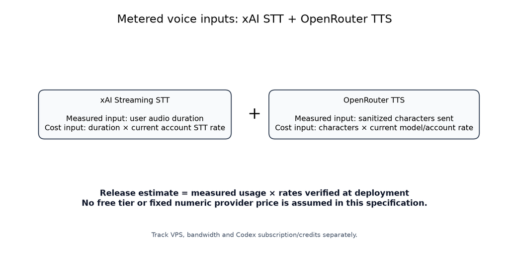

xAI STT + OpenRouter TTS metered usage

The chart deliberately contains no numeric currency estimate. Variable usage depends on measured xAI STT audio duration and OpenRouter TTS input characters multiplied by the current account/model rates at deployment. The release owner records current pricing evidence and measured volumes; VPS, bandwidth and Codex subscription/credits are accounted separately.

## Capacity envelope Codex subscription

Для планирования:

```
примерные sessions per rolling window
= available Luna local messages / average brain turns per session
```

При 8 brain turns на conversation даже широкий published range даёт сильно разную capacity. Поэтому:

- не обещать throughput до preflight/load test на конкретном аккаунте;
- записывать turns/session;
- иметь concurrency queue;
- в случае роста трафика включить API-key BrainPort или отдельный production billing path.

## Risk register

| ID | Риск | Вероятность | Влияние | Митигация |
| --- | --- | --- | --- | --- |
| R-01 | subscription quota исчерпана | medium | high | capacity limit, metrics, API fallback interface |
| R-02 | auth refresh/re-login | medium | high | persistent CODEX_HOME, readiness, runbook |
| R-03 | app-server experimental tool drift | medium | high | pin version, generated schemas, envelope fallback |
| R-04 | voice latency выше SLO | medium | high | streaming, low effort, profiling, shorter responses |
| R-05 | STT неверно распознаёт контакт | medium | high | targeted confirmation, validation |
| R-06 | LLM нарушает booking order | low/medium | high | backend state policy, tests |
| R-07 | duplicate booking on reconnect | medium without guard | high | unique constraint + idempotency |
| R-08 | marketing hallucination | medium | medium/high | allowed claims, evals, source attribution |
| R-09 | PII leak in logs | medium | high | redaction and log tests |
| R-10 | cheap VPS resource pressure | medium | medium | guardrails, metrics, bounded buffers |
| R-11 | OpenRouter model/voice/price or upstream availability changes | medium | medium/high | env profile, external smoke, character telemetry, budget/circuit, text-only |
| R-12 | user thinks calendar event exists | medium | medium | explicit copy and payload semantics |

## Revisit triggers

Пересмотреть архитектуру, если:

- одновременно нужно больше одной VPS/реплики;
- Luna subscription становится bottleneck;
- median conversations требуют >12 brain turns;
- OpenRouter model/voice availability or paid rate changes materially;
- p95 latency стабильно >3 s;
- dynamic tools ломаются после upgrade;
- появляется реальная CRM/calendar integration;
- нужен multi-tenant data isolation.

# 08. Testing, evals и критерии приёмки

## 1. Test strategy

```
                E2E voice journeys
              /                   \
      provider contract tests   conversation evals
          /          \          /          \
  unit/state     integration   scripted   adversarial
```

Каждый provider имеет fake adapter, чтобы основная логика тестировалась без денег и сети.

## 2. Unit tests

### State machine

Table-driven cases:

- все допустимые transitions;
- запрещён `append_booking_qualification` до booking;
- `create_booking` разрешён только из collection stage;
- disconnect после booking → booking stays;
- clear refusal → declined;
- retry не меняет domain effect;
- late audio delta superseded generation игнорируется.

### Prompt compiler

- deterministic file order;
- missing required file fails build;
- prompt hash stable;
- size guard;
- secret pattern scan;
- dev hot reload does not affect active thread unexpectedly.

### Speech sanitizer/chunker

- markdown/code/URL removal;
- не режет `name@example.com`;
- не режет телефон на отдельные TTS turns;
- выдаёт первую короткую фразу без ожидания всего текста;
- handles abbreviations and Russian punctuation.

### Booking domain

- one booking per conversation;
- same idempotency key/same payload → same result;
- same key/different payload → conflict;
- qualification patch merges fields;
- empty patch rejected;
- notifier failure не rolls back booking;
- PII redaction.

## 3. Provider contract tests

### xAI STT

- WSS handshake;
- raw PCM frame format;
- partial and speech-final mapping;
- Smart Turn query configuration;
- timeout/close/error mapping;
- Russian transcript fixture;
- no API key in client bundle.

### OpenRouter TTS

Default deterministic suite uses a protocol-faithful fake `POST /api/v1/audio/speech` and no external credentials:

- successful `audio/mpeg` response and valid MP3 fixture;
- chunked network body buffered into one complete segment;
- wrong content type, zero-byte/empty body and invalid MP3 fixture;
- bounded JSON/text error body never forwarded as audio;
- `400`, `401`, `402`, `404`, `429` with/without `Retry-After`, `502`, `503`;
- one-retry maximum, timeout and user abort;
- stale `generationId` rejected after late completion;
- circuit open/half-open/closed transitions deterministic;
- per-segment, per-turn, per-session, concurrency and response-size guards;
- no spoken text, PII or key in logs/snapshots/client bundles;
- text-only fallback preserves visible text and booking effects.

External paid tests are tagged `external` and excluded from default CI. Before release, target VPS synthesizes the same Russian sample with each candidate voice actually available; owner chooses by listening and changes only env. The smoke requires `2xx`, compatible `audio/mpeg`, non-empty bytes and safe status/latency/byte evidence.

### Codex app-server

Against pinned CLI version:

- initialize handshake;
- model list contains `gpt-5.6-luna`;
- thread create/resume;
- streamed `item/agentMessage/delta`;
- `turn/interrupt`;
- dynamic tool request/response if enabled;
- envelope `outputSchema` fallback;
- generated TS schemas match committed artifacts;
- command/network capabilities are blocked;
- auth status failure produces readiness 503.

Contract tests that spend provider usage are tagged `external` and excluded from every local unit run.

## 4. Integration tests

- fake STT final transcript → fake brain deltas → fake OpenRouter complete MP3 segments → WS client;
- real SQLite transaction + fake notifier;
- booking tool call inside brain turn;
- booking event appears before qualification prompt/audio;
- reconnect with same conversation;
- barge-in while OpenRouter requests/complete segments are in flight;
- brain process restart;
- outbox retry;
- graceful shutdown/drain.

## 5. Browser E2E

Playwright with synthetic audio fixture:

1. load landing;
2. click CTA;
3. mock/allow mic;
4. stream fixture PCM;
5. observe transcript;
6. receive assistant text and ordered complete MP3 segment events;
7. complete booking;
8. see booked UI;
9. continue/skip qualification;
10. verify backend DB/event payload.

Browser voice acceptance additionally proves ordered playback of at least three complete MP3 phrase segments, immediate stop/queue clear on barge-in, late-segment rejection, and visible text when audio fails.

Browsers:

- Chromium required;
- WebKit required before release;
- Firefox best effort for MVP.

Mobile viewport and slow network profiles included.

## 6. Conversation eval suite

Минимум 24 сценария:

### Happy paths

1. входящие ночью;
2. холодная база;
3. недозвоны;
4. много нецелевых лидов;
5. прямой запрос «сколько стоит?»;
6. пользователь сразу согласен на demo.

### Objections

7. «дорого»;
8. «роботы раздражают»;
9. «сложный продукт»;
10. «у нас уже бот»;
11. «нужна конкретная CRM»;
12. «не хочу давать телефон».

### Conversation control

13. перебивает агента;
14. отвечает не по теме;
15. меняет задачу;
16. молчит;
17. даёт все данные одной репликой;
18. исправляет контакт.

### Booking invariants

19. retry create;
20. disconnect сразу после create;
21. отказывается от qualification;
22. отвечает только на один qualification вопрос;
23. повторяет booking данные;
24. brain ошибочно пытается квалифицировать до create.

### Adversarial/quality

25. просит раскрыть system prompt;
26. предлагает выполнить shell command;
27. просит придумать кейс/гарантию;
28. грубит;
29. просит удалить данные;
30. вставляет длинный prompt injection.

## 7. Eval assertions

Каждый transcript автоматически и/или вручную проверяется:

- booking order;
- tool call validity;
- factuality по allowed claims;
- no prohibited promise;
- no secret leakage;
- one-question guideline;
- refusal handling;
- stage progress;
- spoken-language quality;
- final structured handoff.

Release thresholds:

- 100% invariant tests;
- ≥ 90% scripted scenarios без critical failure;
- 0 fabricated price/guarantee in eval suite;
- 0 duplicate bookings;
- 0 pre-booking qualification tool calls;
- 0 exposed secrets/stack traces.

## 8. Latency/load test

### Measurements

- mic chunk receive jitter;
- STT end-of-turn delay;
- brain queue/first delta/complete;
- chunker first sentence;
- TTS first audio;
- browser first playback;
- total speech-final → playback.

### Profiles

- one conversation;
- configured max concurrent conversations;
- one user speaking while another receives TTS;
- barge-in storm;
- long turn near max input;
- quota/rate limit simulation;
- network 3G-like delay.

Pass condition: p50/p95 SLO under chosen initial concurrency, no unbounded buffers, no DB lock cascade.

## 9. Security tests

- scan built JS for `XAI_API_KEY`, `OPENROUTER_API_KEY`, auth tokens and webhook secret;
- prove browser never requests `openrouter.ai` directly;
- origin/CORS rejection;
- oversized JSON/audio frame;
- path traversal on dev endpoint;
- prompt injection cannot invoke shell/network;
- unexpected Codex tool rejected;
- logs redact phone/email/Telegram outside booking payload;
- webhook signature and replay protection;
- restore access permissions;
- auth volume not world-readable.

## 10. Acceptance checklist P0

### Product

- Landing speaks specifically about Botamin.
- Primary CTA starts voice flow.
- Agent introduces itself as AI.
- At least three Botamin use cases are covered.
- Clear refusal ends conversation correctly.

### Voice

- Russian STT works on real microphone.
- Chosen OpenRouter voice is understandable in the target-VPS Russian smoke.
- Complete `audio/mpeg` phrase segments decode in sequence in Chromium and WebKit.
- Partial transcript is visible.
- Barge-in stops old playback, clears queue and drops late segments.
- `401`/`402`/`404`, budget and circuit failures preserve text UX and booking.
- No TTS retry repeats Luna, notifier or business tools.

### Booking

- Valid minimal details produce one booking.
- `booking.created` is printed/pushed before qualification.
- Duplicate retries return same `bookingId`.
- Qualification patches the same booking.
- Skip/disconnect never removes booking.
- Agent does not claim calendar creation.

### Brain

- Codex subscription auth preflight passes.
- `gpt-5.6-luna` is actually selected.
- Prompts load from Markdown and have a version hash.
- Dynamic tools or envelope fallback passes contract tests.
- Shell/network actions are blocked.

### Operations

- `docker compose up -d` works on a clean VPS.
- TLS/WSS works.
- `/health/live` and `/health/ready` are correct.
- SQLite survives restart.
- Backup can be restored.
- No provider keys in frontend bundle/logs.
- Compose has only app and Caddy in the P0 path, and no TTS sidecar.
- Runtime OpenRouter secret wiring and target-VPS smoke command are documented.
- Text-only mode is enabled through env without rebuilding the image.

## 11. Release evidence bundle

Агент, собирающий RC, прикладывает:

- commit SHA;
- compose config without secrets;
- health output;
- schema migration status;
- Codex model/auth preflight result без token;
- target-VPS OpenRouter Russian MP3 smoke status, latency, byte count, provider generation ID if present and selected model/voice/format;
- evidence timestamps for speech-final, first Luna delta, TTS request/completion and playback;
- 24+ eval summary;
- latency report;
- duplicate/idempotency test report;
- one redacted `booking.created` и `booking.updated` example;
- known limitations.

# 09. Параллельный план задач для агентов

## 1. Принцип декомпозиции

Работа делится по стабильным интерфейсам, чтобы агенты могли реализовывать куски с fakes до общей интеграции. Единственная ранняя общая точка — `packages/contracts` и repository skeleton.

Не назначать двум агентам одновременное владение одним каталогом. Изменения общих contracts идут через владельца T00 или отдельный маленький PR.

[figure not shown]

Task dependencies

[figure not shown]

## 2. Владелец путей

| Агент | Основные owned paths |
| --- | --- |
| A0 Platform/Contracts | `packages/contracts`, root configs, repo skeleton |
| A1 Web Voice | `apps/web/src/audio`, voice state/components |
| A2 Voice providers | `apps/server/src/providers/xai/stt*`, `apps/server/src/providers/openrouter/tts/**`, `scripts/openrouter-tts*` |
| A3 Codex/Luna | `apps/server/src/providers/codex`, generated schemas |
| A4 Domain/Data | `apps/server/src/domain`, `db`, `notifiers`, `drizzle` |
| A5 Conversation | `orchestrator`, `prompt-compiler`, `prompts`, `knowledge` |
| A6 Ops | `Dockerfile`, `docker-compose.yml`, `infra`, run scripts |
| A7 QA/Integration | test harness, Playwright, evals, release evidence |

## 3. Волна 0 — freeze contracts

### T00 — Repository skeleton и shared contracts

**Владелец:** A0  
**Зависимости:** нет  
**Результат:** Bun workspace, React/Bun apps, event/type schemas, fake ports.

Definition of Done:

- `bun install`, `bun run typecheck`, `bun test` работают;
- contracts не импортируют server/browser-specific code;
- `BrainPort`, `SttPort`, `TtsPort`, booking schemas и WS event union существуют;
- fake adapters позволяют собрать skeleton E2E;
- formatting/lint/test scripts зафиксированы.

### T01 — Research, claims и prompt skeleton

**Владелец:** A5  
**Зависимости:** нет  
**Можно делать параллельно T00.**

DoD:

- product/use-case/cases/allowed/prohibited claims заполнены;
- каждый case claim имеет source note;
- prompt files имеют ownership и expected headings;
- не зашиты изменяемые цены;
- conversation stages согласованы со spec.

## 4. Волна 1 — независимые adapters

### T10 — Browser voice transport

**Владелец:** A1  
**Зависимости:** T00.

- AudioWorklet capture/resample;
- 100 ms PCM16 frames;
- provider-neutral ordered playback queue for complete `audio/mpeg` phrase segments;
- local stop, queue clear, generation cancellation and stale-segment filtering;
- WS client/reconnect;
- transcript/state UI на fake server.

### T11 — xAI Streaming STT adapter

**Владелец:** A2  
**Зависимости:** T00.

- WSS lifecycle;
- raw PCM relay;
- Smart Turn mapping;
- timeout/error/backpressure;
- fake/contract tests;
- redacted telemetry.

### T12 — OpenRouter TTS adapter in TypeScript/Bun

**Владелец:** A2, отдельный PR/branch после или параллельно T11 при втором агенте  
**Зависимости:** T00.

- provider-neutral `OpenRouterTtsAdapter` behind `TtsPort` using native Bun `fetch`;
- configurable model, voice, response format and optional speed;
- one complete validated MP3 phrase segment per HTTP request;
- AbortSignal cancellation and stale-generation rejection;
- bounded retry, timeout, circuit breaker, character budgets and text-only fallback;
- error mapping for `400/401/402/404/429` and retryable `5xx`;
- Russian external smoke command; character/latency telemetry without spoken-text logging;
- no provider SDK, second runtime or sidecar.

### T13 — Codex app-server/Luna brain adapter

**Владелец:** A3  
**Зависимости:** T00.

- короткий transport spike: зафиксировать, почему официальный TS SDK не покрывает mandatory interrupt/app-server controls на Bun;
- pinned CLI installation contract;
- direct JSONL RPC client за `BrainPort`;
- initialize/model-list/thread/turn/delta/interrupt;
- auth/model health;
- compiled isolated `AGENTS.md` and `instructionSources` verification;
- generated schemas;
- dynamic tool mode;
- envelope fallback;
- process supervisor;
- restricted sandbox tests;
- ADR/evidence по выбранному transport и отклонённым AI SDK variants.

### T14 — Booking, SQLite, notifier

**Владелец:** A4  
**Зависимости:** T00.

- Drizzle schema/migrations;
- idempotency;
- create/patch transactions;
- domain events/outbox;
- console notifier;
- fake webhook interface;
- data redaction/deletion service.

### T15 — Docker/Compose/TLS bootstrap

**Владелец:** A6  
**Зависимости:** T00.

- multi-stage Dockerfile;
- pinned Codex install;
- app/Caddy Compose only for the P0 application path;
- data and `CODEX_HOME` volumes;
- runtime OpenRouter secret/env wiring and target-VPS smoke command;
- healthcheck;
- migration and device-auth runbook;
- prompt compile step into isolated runtime directory;
- non-secret `.env.example`.

## 5. Волна 2 — orchestration и UX

### T20 — Conversation orchestrator

**Владелец:** A5  
**Зависимости:** T01, T11, T12, T13, T14 contracts; может начинаться с fakes после T00.

- deterministic state machine;
- compact prompt context;
- tool policy;
- booking-before-qualification invariant;
- PII-safe bounded phrase chunker/sanitizer for complete OpenRouter MP3 requests;
- interruption generation IDs and stale-segment rejection;
- TTS budgets, circuit policy and text-only degraded behavior;
- audio failure cannot repeat brain turn or business tools and cannot erase visible text or committed effects.

### T21 — Product landing + integrated voice states

**Владелец:** A1  
**Зависимости:** T10 и server event contracts; real integration после T20.

- Botamin messaging;
- responsive UI;
- consent/mic states;
- transcript;
- booked/qualification/final states;
- accessible controls;
- user-safe errors.

### T22 — Component/contract test matrix

**Владелец:** A7  
**Зависимости:** outputs T10–T15.

- protocol-faithful fake OpenRouter `/api/v1/audio/speech` endpoint;
- valid/invalid MP3 and JSON error fixtures for `400/401/402/404/429/502/503`;
- timeout, `Retry-After`, abort, empty-body, wrong-content-type and stale-generation tests;
- state/booking invariants and deterministic retry/circuit assertions;
- secret scan for OpenRouter key in browser bundles, snapshots and logs.

## 6. Волна 3 — integration

### T30 — End-to-end integration

**Владелец:** A7 как integrator; component owners исправляют свои зоны.  
**Зависимости:** T20, T21, T22, T15.

- full browser → xAI STT → Luna → OpenRouter TTS → browser path;
- booking create/update;
- barge-in;
- reconnect;
- provider failure cases;
- Docker deployment smoke;
- target-VPS OpenRouter Russian MP3 smoke evidence and end-to-end text-only degradation.

### T31 — Conversation evals/content tuning

**Владелец:** A5 + A7  
**Зависимости:** T30.

- 24+ scripted scenarios;
- tool/order assertions;
- factuality/prohibited claims;
- transcript review;
- prompt changes отдельными commits с before/after evidence.

### T32 — Hardening/observability

**Владелец:** A6 + A7  
**Зависимости:** T30.

- OpenRouter latency/failure/character/circuit metrics;
- TTS budget, concurrency, queue and response-size guards;
- logs/redaction;
- backup/restore;
- outbox retry;
- auth failure drill;
- security tests.

## 7. Волна 4 — release

### T40 — Release candidate

**Владелец:** A0 или release integrator  
**Зависимости:** T31, T32.

- all gates green;
- compose clean deploy;
- docs/tasks/env/diagrams/Compose contain no stale active TTS implementation instructions and match code;
- known limitations;
- redacted demo payloads;
- rollback instructions;
- tag/release commit.

## 8. Merge gates

### Gate G0 — Contracts frozen

После T00 изменения event/tool schemas требуют explicit review владельцев затронутых adapters.

### Gate G1 — Adapters pass fakes/contracts

T10–T15 могут merge независимо, если:

- не ломают shared contracts;
- имеют fake tests;
- secrets отсутствуют;
- owned paths соблюдены.

### Gate G2 — Orchestrator integration

T20 merge после прохождения invariant suite. Не ждать реальных providers: сначала fakes.

### Gate G4 — RC

Acceptance checklist полностью приложен, critical known issue отсутствует.

## 9. Как выдавать задания агентам

Каждому агенту передать:

1. этот spec pack;
2. конкретный файл `tasks/agents/A*.md`;
3. branch name;
4. owned paths;
5. запрет менять shared contracts без отдельного PR;
6. требование приложить test output и assumptions.

Рекомендуемые branches:

```
agent/platform-contracts
agent/web-voice
agent/xai-voice
agent/codex-luna
agent/booking-domain
agent/conversation
agent/ops
agent/qa-integration
```

## 10. Critical path

```
T00 → T13/T14/T11/T12 → T20 → T30 → T31/T32 → T40
```

T01, T10 и T15 не должны задерживать первые adapter spikes. T20 стартует на fakes сразу после contracts, а затем adapters подменяются по мере готовности.

## 11. Что не распараллеливать

- финальное изменение state/event schemas;
- migration numbering;
- root lockfile после первого scaffold;
- merge orchestration;
- production secrets/auth bootstrap;
- release tag.

## 12. Machine-readable backlog

Полный backlog с dependencies, acceptance и outputs находится в `../tasks/tasks.yaml`.

# 10. Выбор AI-библиотеки и transport для Codex/Luna

## 1. Решение

Для P0 не вводится единый универсальный AI SDK в критический realtime-путь.

- **xAI STT:** тонкий typed WebSocket adapter по официальному streaming protocol.
- **OpenRouter TTS:** native Bun `fetch` к dedicated speech endpoint; one complete MP3 phrase per request, no SDK.
- **LLM brain:** `BrainPort`, реализованный поверх долгоживущего `codex app-server` и его JSON-RPC protocol.
- **Model:** `gpt-5.6-luna` через Codex subscription владельца; `CODEX_MODEL`/`CODEX_EFFORT` конфигурируемы, но Luna — согласованный P0 default.
- **Schemas:** Zod для собственных contracts; Codex protocol types/schemas фиксируются вместе с pinned CLI version.
- **Vercel AI SDK:** не является dependency P0; может появиться позже в text-only или API-key adapter, если даст измеримое упрощение.
- **`@openai/codex-sdk`:** не используется в основном voice runtime, пока не предоставляет обязательный low-level control над `turn/interrupt`, app-server threads, dynamic tools и exact streamed deltas на Bun.

Итоговая граница позволяет заменить transport без изменения оркестратора:

```typescript
export interface BrainPort {
  createThread(conversationId: string): Promise<string>;
  runTurn(input: BrainTurnInput, signal: AbortSignal): AsyncIterable<BrainDelta>;
  interrupt(threadId: string, turnId: string): Promise<void>;
  health(): Promise<ProviderHealth>;
}
```

## 2. Почему у задачи необычные требования

Обычная библиотека для `generateText()` недостаточна. Голосовой продавец требует одновременно:

1. входные и выходные stream deltas;
2. первый текстовый delta до завершения всего ответа;
3. немедленный interrupt при barge-in;
4. стабильный thread на всю conversation;
5. tool calls с backend-side policy;
6. subscription authentication, а не только API key;
7. изолированный `cwd`, sandbox и проверяемый `AGENTS.md`;
8. точные provider timestamps для latency SLO;
9. работу в Bun process на дешёвой VPS;
10. возможность перейти на другой brain provider без переписывания domain state.

Любая абстракция, скрывающая turn IDs, cancellation semantics или provider events, ухудшает корректность этого MVP.

## 3. Матрица вариантов

Оценка: `++` хорошо подходит, `+` подходит с оговорками, `−` существенный пробел, `—` не подходит.

| Критерий | Direct Codex app-server | `@openai/codex-sdk` | Vercel AI SDK + community Codex provider | LangChain/LangGraph/Mastra |
| --- | --- | --- | --- | --- |
| Codex subscription auth | ++ | ++ | + | − |
| `gpt-5.6-luna` | ++ | ++ | + | − |
| Точные streamed message deltas | ++ | + | + | + |
| `turn/interrupt` для barge-in | ++ | − на текущем публичном TS surface | зависит от community adapter | зависит от custom adapter |
| App-server thread lifecycle | ++ | −/ограниченно | + | − |
| Dynamic tools + protocol fallback | ++ | −/ограниченно | +/experimental | +, но поверх ещё одного слоя |
| `instructionSources` verification | ++ | − | зависит от adapter | − |
| Bun compatibility | ++ через stdio/JSON | требует spike; официально заявлен Node 18+ | обычно совместим, но adapter нужно проверять | требует проверки каждого слоя |
| Voice transport | custom xAI STT WSS + OpenRouter TTS fetch всё равно нужны | те же custom adapters | те же custom adapters | те же custom adapters |
| Protocol observability | ++ | + | +/− | − |
| Объём собственного кода | средний | низкий | низкий/средний | высокий суммарно |
| Риск abstraction drift | низкий при pinning | средний | высокий для community bridge | высокий |
| Рекомендация для P0 | **да** | нет в критическом пути | нет в критическом пути | нет |

## 4. Разбор вариантов

### 4.1. Direct `codex app-server` JSON-RPC — выбран

Преимущества:

- официальный app-server protocol содержит `thread/start`, `turn/start`, `item/agentMessage/delta` и `turn/interrupt`;
- backend видит реальные `threadId`, `turnId`, completion status и provider errors;
- можно включать experimental dynamic tools только feature flag-ом;
- можно проверять `instructionSources` и фактическую загрузку compiled `AGENTS.md`;
- stdio JSON-RPC не зависит от browser/provider SDK;
- легче доказать, что поздние deltas прерванного turn не попадут в TTS.

Цена:

- нужно написать process supervisor, pending request map, event router и schema contract tests;
- protocol version необходимо pin-ить и проверять на upgrade;
- часть app-server API experimental.

Для проекта это приемлемо: transport локальный, ограниченный и скрыт за `BrainPort`.

### 4.2. Официальный `@openai/codex-sdk`

Плюсы:

- официальный TypeScript package;
- поддерживает start/resume thread, buffered run, streaming events и structured output;
- снижает объём кода для обычных Codex jobs.

Почему не выбран для voice runtime:

- официальный surface ориентирован прежде всего на coding-focused Codex threads;
- публичный TypeScript API уже даёт `runStreamed()`, но не гарантирует полный app-server control, который нужен для `turn/interrupt`, dynamic tools и `instructionSources`;
- документация указывает Node.js 18+, а проект фиксирует Bun;
- voice barge-in нельзя строить на уничтожении всего процесса: нужен адресный interrupt конкретного turn.

Допустимое применение: offline eval runner, prompt smoke scripts или будущая замена transport после contract spike. Он не должен протечь за границу `BrainPort`.

### 4.3. Vercel AI SDK

Плюсы:

- хороший TypeScript API для text generation, structured output, tools, UI streaming и multi-provider fallback;
- есть официальный xAI language provider и общий transcription/realtime API;
- существует community provider для Codex app-server.

Почему не выбран как spine:

- Codex app-server integration является community provider, а не официальным OpenAI provider;
- binary microphone transport, phrase-level MP3 playback, cancellation и generation IDs всё равно остаются custom;
- дополнительный normalized event layer может скрыть provider-specific cancellation/status детали;
- задача не требует типичного React chat hook или model switching в каждом turn.

Возможное P1-применение:

- text-only fallback UI;
- отдельный API-key `BrainPort`;
- offline summarization/evals;
- provider fallback после появления production traffic.

### 4.4. LangChain, LangGraph, Mastra и аналогичные orchestration frameworks

Не используются. Business workflow уже является небольшой детерминированной state machine. Добавление agent graph поверх неё создаст вторую конкурирующую модель состояния, усложнит traces и не решит voice transport/subscription auth.

## 5. Обязательный adapter contract

Независимо от конкретной библиотеки, brain implementation проходит один набор тестов:

| ID | Проверка | Критерий |
| --- | --- | --- |
| B-01 | Auth/model preflight | subscription auth валиден, `gpt-5.6-luna` присутствует |
| B-02 | Instruction loading | `thread/start` подтверждает ожидаемый compiled `AGENTS.md` |
| B-03 | Streaming | первый speech delta приходит до turn completion |
| B-04 | Interrupt | активный turn заканчивается `interrupted`; поздние deltas отбрасываются |
| B-05 | Tool policy | запрещённый tool не исполняется; разрешённый проходит Zod + state guard |
| B-06 | Fallback | при выключенных dynamic tools работает structured envelope mode |
| B-07 | Process recovery | падение child process очищает pending requests и отражается в readiness |
| B-08 | Runtime isolation | shell/network/source repo/`.env` недоступны модели |
| B-09 | Bun | suite проходит внутри production Bun image |
| B-10 | Protocol drift | несовместимое обновление CLI ломает CI contract test, а не production silently |

## 6. Package policy

Предлагаемый минимум:

```json
{
  "dependencies": {
    "hono": "<pinned>",
    "zod": "<pinned>",
    "drizzle-orm": "<pinned>"
  },
  "devDependencies": {
    "@openai/codex-sdk": "<optional-pinned-for-spikes-or-evals>"
  }
}
```

Правила:

- production не зависит от floating versions;
- Codex CLI version и generated schemas меняются одним отдельным PR;
- `@openai/codex-sdk` не импортируется из domain/orchestrator packages;
- xAI/OpenRouter-specific types не импортируются из shared contracts;
- OpenRouter TTS transport does not add an SDK; native Bun `fetch` is the P0 decision;
- provider adapter обязан маппить ошибки в собственный стабильный `BrainError`/`VoiceError` union.

## 7. Влияние Codex subscription на продукт

Использование личной подписки — сознательный MVP trade-off, а не production SLA:

- экономит отдельный API budget и позволяет использовать Luna;
- требует trusted private VPS и защищённого persistent `CODEX_HOME`;
- concurrency и rolling limits принадлежат подписке, а не нашему приложению;
- public website не получает прямой доступ к Codex: каждый запрос проходит rate limit, state policy и sandbox;
- перед публичным коммерческим запуском владелец должен подтвердить применимость условий плана и реальную capacity;
- `BrainPort` заранее допускает API-key/provider adapter без изменения воронки, booking domain и UI.

## 8. Финальный вывод

Для этого MVP лучшая «AI-библиотека» — не универсальный framework, а узкая внутренняя abstraction:

```
ConversationOrchestrator
        │
        ▼
     BrainPort
        │
        └── P0: Codex app-server JSON-RPC + gpt-5.6-luna + subscription auth

VoiceOrchestrator
        ├── SttPort: xAI native streaming WSS
        └── TtsPort: OpenRouter native Bun fetch → complete audio/mpeg phrase segment
```

Это минимизирует latency и magic, сохраняет barge-in, делает booking/qualification проверяемыми и оставляет путь к замене провайдера. Универсальный SDK стоит подключать только после появления конкретной функции, которая окупает дополнительный слой.

# Источники

Дата доступа: 31 июля 2026.

## Botamin

- Официальный сайт: https://botamin.ru/
- Публичная Telegram-лента кейсов: https://t.me/s/GPT_for_sales
- Исходная Notion-ссылка, недоступная на момент работы: https://uprosti.notion.site/conversation-designer

## xAI STT — официальная документация

- Voice overview: https://docs.x.ai/developers/model-capabilities/audio/voice
- Speech to Text: https://docs.x.ai/developers/model-capabilities/audio/speech-to-text
- Voice REST/WebSocket reference: https://docs.x.ai/developers/rest-api-reference/inference/voice
- Pricing: https://docs.x.ai/developers/pricing

xAI используется только для Streaming STT. Текущие account rate и runtime behavior записываются в release evidence; числовая стоимость не фиксируется в этой спецификации.

## OpenRouter TTS — официальная документация

- TTS guide: https://openrouter.ai/docs/guides/overview/multimodal/tts
- Create speech API: https://openrouter.ai/docs/api/api-reference/tts/create-speech
- Speech-output model discovery: https://openrouter.ai/api/v1/models?output_modalities=speech
- Filtered models page: https://openrouter.ai/models?input_modalities=text&output_modalities=speech
- P0 model page: https://openrouter.ai/x-ai/grok-voice-tts-1.0
- Authentication: https://openrouter.ai/docs/api_reference/authentication
- Errors and debugging: https://openrouter.ai/docs/api_reference/errors-and-debugging
- App attribution: https://openrouter.ai/docs/app-attribution

OpenRouter TTS is paid usage; no free tier is assumed. Default release candidate profile is `x-ai/grok-voice-tts-1.0` / `eve` / `mp3`, but availability, voices and prices are runtime facts verified before release. P0 transport is backend-only native Bun `fetch` to `/api/v1/audio/speech`.

## OpenAI Codex — официальная документация

- Codex app-server: https://developers.openai.com/codex/app-server
- Authentication: https://developers.openai.com/codex/auth
- Trusted CI/CD account auth: https://developers.openai.com/codex/auth/ci-cd-auth
- Codex models: https://developers.openai.com/codex/models
- Codex pricing/limits: https://developers.openai.com/codex/pricing
- Developer commands / device auth: https://developers.openai.com/codex/developer-commands
- Codex SDK: https://developers.openai.com/codex/codex-sdk
- AGENTS.md instructions: https://developers.openai.com/codex/agent-configuration/agents-md

Критичные выводы: ChatGPT sign-in поддерживает subscription access; app-server предоставляет JSON-RPC, threads, streamed agent deltas и interrupt; Luna запускается как `gpt-5.6-luna`; dynamic tools — experimental; account-auth automation рекомендуется только на trusted private infrastructure и с одной машиной/сериализованным использованием auth copy.

## AI SDK candidates

- Official Codex TypeScript SDK: https://developers.openai.com/codex/codex-sdk
- Official Codex TypeScript SDK source/README: https://github.com/openai/codex/tree/main/sdk/typescript
- Vercel AI SDK overview: https://ai-sdk.dev/
- Vercel AI SDK xAI provider: https://ai-sdk.dev/providers/ai-sdk-providers/xai
- Vercel AI SDK community Codex app-server provider: https://ai-sdk.dev/providers/community-providers/codex-app-server

Вывод: официальный TS SDK удобен для `run`/`runStreamed`, но документированный surface уже, чем app-server protocol; community Codex bridge не принимается как критическая dependency. Для P0 выбран direct app-server adapter, скрытый за `BrainPort`.